# 高级R第二版-基础部分

Studennt. LI Junjie

Dongbei University of Finance & Economics

2020-08-05

# 欢迎

```r
# 数据探索
library(pacman)
p_load(tidyverse,DT,skimr,DataExplorer,explore,vtable,stringr,kableExtra,lubridate)
```

*“Advanced R solutions”* by Malte Grosser and Henning Bumann, provides worked solutions to the exercises in this book.

*“R for Data Science”* which introduces you to R as a tool for doing data science, focussing on a consistent set of packages known as the tidyverse.

*“R Packages”* which teaches you how to make the most of R’s fantastic package system.

# 1 前言

## 1.1 优点太多，只讨论缺点:

- 大部分R代码都是匆忙编写的，目的是解决一个紧迫的问题。结果，代码不是非常优雅，快速或易于理解。大多数用户不会修改其代码来解决这些缺点。
- 与其他编程语言相比，R社区更注重结果而不是过程(少写函数多应用)。软件工程最佳实践的知识是零散的。例如，没有足够的R程序员使用源代码控制或自动测试
- 元编程是一把双刃剑。太多的R函数使用技巧来减少键入量，但所付出的代价是编写难以理解的代码，并可能以意想不到的方式失败。
- 各个贡献包之间甚至在基本R中都存在不一致的情况。每次使用R都会面临超过25年的发展，这会使学习R变得困难，因为要记住的**特殊情况**很多。
- R不是特别快的编程语言，编写不佳的R代码可能会非常慢。 R还是记忆的挥霍用户。

我个人认为，这些挑战为经验丰富的程序员创造了一个很好的机会，可以对R和R社区产生深远的积极影响。R用户确实很在意编写高质量的代码，特别是对于可重复的研究，但是他们还没有技巧。我希望这本书不仅可以帮助更多的R用户成为R程序员，而且可以鼓励其他语言的程序员为R做出贡献。

## 1.2 读完这本书能学到什么？

了解函数式编程的含义，以及为什么它是数据科学的有用工具。您将能够快速学习如何使用现有工具，并具有在需要时创建自己的功能性工具的知识。

了解R丰富的面向对象系统。 您将最熟悉S3，但是您将了解S4和R6，以及在需要时可以在何处查找更多信息。

欣赏元编程的双刃剑。 您将能够创建使用整洁的评估功能，保存键入内容并创建精美的代码来表达重要的操作。 您还将了解危险以及何时避免危险。

对于R中的运算速度较慢或占用大量内存的情况，要有一个很好的直觉。 您将了解如何使用性能分析来找出性能瓶颈，并且您将了解足够的C ++将慢速R函数转换为快速C ++等效项。

## 1.3 提高编程能力

阅读源代码很重要，因为它可以帮助您编写更好的代码。开始开发此技能的好地方是查看您最常使用的功能和程序包的源代码。您会发现值得在您自己的代码中模仿的东西，并且会对制作好的R代码产生一种品味。您还会看到自己不喜欢的事物，这可能是因为其优点不明显或冒犯了您的敏感性。尽管如此，这样的代码还是有价值的，因为它有助于使您对好的和坏的代码发表具体的看法。

学习R时，科学的心态非常有帮助。如果您不了解某些事物的工作原理，则应提出假设，设计一些实验，进行实验并记录结果。该**练习**非常有用，因为如果您无法解决问题并需要帮助，则可以轻松地向他人展示您的尝试。另外，当您找到正确的答案时，便会做好心理准备来更新自己的世界观。

## 1.4 帮助文档

目前，有三个主要的途径可以让你在遇到困难或者找不出问题原因时得到帮助:RStudio社区、StackOverflow和R-help邮件列表。你可以在每个地方得到很好的帮助，但是他们有自己的文化和期望。在你发布第一个帖子之前，花点时间学习一下，了解一下社区的期望通常是个好主意。

如果您正在寻找解决本书中**练习**的特定帮助，请访问https://advanced-r-solutions.rbind.io，获取Malte Grosser和Henning Bumann的解决方案。

# 2 名称和数值

## 2.1 介绍

```r
df <- data.frame(x = rnorm(3),y = rnorm(3))
df %>% head()
```

|  | x | y |
| --- | --- | --- |
| 1 | -3.0903323 | -0.4498609 |
| 2 | 0.5299323 | -0.3647004 |
| 3 | 1.0087453 | 0.6261394 |

```r
df$z <- df$x + df$y
df %>% head()
```

|  | x | y | z |
| --- | --- | --- | --- |
| 1 | -3.0903323 | -0.4498609 | -3.5401931 |
| 2 | 0.5299323 | -0.3647004 | 0.1652319 |
| 3 | 1.0087453 | 0.6261394 | 1.6348846 |

```r
x <- rnorm(100000)
y <- list(x,x,x)
# y
lobstr::obj_size(x)
```

```
800,048 B
```

```r
lobstr::obj_size(y)
```

```
800,128 B
```

## 2.2 捆绑基础

```r
x <- 1:10
y <- x
lobstr::obj_addr(x)
```

```
[1] "0x18982340"
```

```r
lobstr::obj_addr(y)  # 指向的地址是一样的
```

```
[1] "0x18982340"
```

**练习**：

```r
a <- 1:10
b <- a
c <- b
d <- 1:10
map(list(a,b,c,d),~lobstr::obj_addr(.x))
```

```
[[1]]
[1] "0x182e0d58"

[[2]]
[1] "0x182e0d58"

[[3]]
[1] "0x182e0d58"

[[4]]
[1] "0x14d99968"
```

```r
mean %>% lobstr::obj_addr()
```

```
[1] "0x11f93fb0"
```

```r
base::mean %>% lobstr::obj_addr()
```

```
[1] "0x11f93fb0"
```

```r
get("mean") %>% lobstr::obj_addr()
```

```
[1] "0x11f93fb0"
```

```r
evalq(mean) %>% lobstr::obj_addr()
```

```
[1] "0x11f93fb0"
```

```r
match.fun("mean") %>% lobstr::obj_addr()
```

```
[1] "0x11f93fb0"
```

```r
?read.csv # check.names
```

## 2.3 复制修改

## 2.4 Object size

```r
lobstr::obj_size(diamonds)
```

```
3,456,344 B
```

```r
pryr::object_size(diamonds)
```

```
3.46 MB
```

**练习**：

```r
object.size(diamonds)
```

```
3456848 bytes
```

```r
pryr::object_size(diamonds)
```

```
3.46 MB
```

```r
lobstr::obj_size(diamonds)
```

```
3,456,344 B
```

```r
a <- runif(1e6)
obj_size(a)
```

```
8,000,048 B
```

```r
b <- list(a, a)
obj_size(b)
```

```
8,000,112 B
```

```r
obj_size(a, b)
```

```
8,000,112 B
```

```r
b[[1]][[1]] <- 10
obj_size(b)
```

```
16,000,160 B
```

```r
obj_size(a, b)
```

```
16,000,160 B
```

```r
b[[2]][[1]] <- 10
obj_size(b)
```

```
16,000,160 B
```

```r
obj_size(a, b)
```

```
24,000,208 B
```

## 2.5 Modify-in-place

```r
x <- data.frame(matrix(runif(5 * 1e4), ncol = 5))
x %>% head()
```

|  | X1 | X2 | X3 | X4 | X5 |
| --- | --- | --- | --- | --- | --- |
| 1 | 0.31541852 | 0.59697466 | 0.2074927 | 0.14951200 | 0.8997062 |
| 2 | 0.33280103 | 0.27063644 | 0.4208540 | 0.96717641 | 0.3676245 |
| 3 | 0.03144739 | 0.25169546 | 0.1157543 | 0.19192377 | 0.8409698 |
| 4 | 0.52898205 | 0.20516495 | 0.5151018 | 0.66922936 | 0.2953020 |
| 5 | 0.13940378 | 0.06603486 | 0.9289403 | 0.03032134 | 0.1908289 |
| 6 | 0.55673361 | 0.66843351 | 0.1789846 | 0.30861535 | 0.1394406 |

```r
medians <- vapply(x, median, numeric(1))
medians
```

```
       X1        X2        X3        X4        X5
0.5061776 0.4991874 0.4903013 0.5040662 0.4965187
```

```r
x[1] %>% head()
```

|  | X1 |
| --- | --- |
| 1 | 0.31541852 |
| 2 | 0.33280103 |
| 3 | 0.03144739 |
| 4 | 0.52898205 |
| 5 | 0.13940378 |
| 6 | 0.55673361 |

```r
x[[1]] %>% head()
```

```
[1] 0.31541852 0.33280103 0.03144739 0.52898205 0.13940378 0.55673361
```

```r
for (i in seq_along(medians)) {
  x[[i]] <- x[[i]] - medians[[i]]
}
x %>% as_tibble()   # 很慢，i也保留了
```

| X1 | X2 | X3 | X4 | X5 |
| --- | --- | --- | --- | --- |
| -0.1907591058 | 0.0977872607 | -0.28280861001 | -0.35455418751 | 0.40318747389 |
| -0.1733765970 | -0.2285509558 | -0.06944730459 | 0.46311022597 | -0.12889426306 |
| -0.4747302434 | -0.2474919384 | -0.37454696721 | -0.31214242056 | 0.34445108019 |
| 0.0228044158 | -0.2940224545 | 0.02480053552 | 0.16516317241 | -0.20121668710 |
| -0.3667738528 | -0.4331525393 | 0.43863897468 | -0.47374484711 | -0.30568985373 |
| 0.0505559784 | 0.1692461112 | -0.31131668878 | -0.19545083633 | -0.35707814817 |
| -0.4467675514 | -0.3070669390 | -0.26130033005 | -0.47929210961 | -0.00072209665 |
| 0.4769964383 | -0.3481153502 | -0.45993211074 | 0.37956613046 | -0.39653554012 |
| -0.1638290903 | 0.2122543455 | 0.48520035157 | 0.31668828335 | 0.36610968492 |
| -0.4190768562 | -0.3887484603 | -0.18729976634 | -0.27241276857 | -0.42252663814 |

[output cut: 9990 more lines]

```r
y <- data.frame(matrix(runif(5 * 1e4), ncol = 5))
medians <- vapply(y, median, numeric(1))
map(seq_along(medians),function(i){
  y[[i]] <- y[[i]] - medians[[i]]
}) %>% bind_cols() -> y
```

```
* NA -> ...1
* NA -> ...2
* NA -> ...3
* NA -> ...4
* NA -> ...5
```

```r
map(y,mean)
```

```
$...1
[1] 0.001904285

$...2
[1] -0.0005124021

$...3
[1] -0.003361683

$...4
[1] 0.001483765

$...5
[1] -0.005262889
```

## 2.6 [本章答案](https://advanced-r-solutions.rbind.io/names-and-values.html)

```r
mean %>% obj_addr()
```

```
[1] "0x11f93fb0"
```

```r
base::mean %>% obj_addr()
```

```
[1] "0x11f93fb0"
```

```r
get("mean") %>% obj_addr()
```

```
[1] "0x11f93fb0"
```

```r
evalq(mean) %>% obj_addr()
```

```
[1] "0x11f93fb0"
```

```r
match.fun("mean") %>% obj_addr()
```

```
[1] "0x11f93fb0"
```

```r
make.names("")
```

```
[1] "X"
```

Why is tracemem(1:10) not useful?

A: When 1:10 is called an object with an address in memory is created, but it is **not bound to a name**. Therefore, the object cannot be called or manipulated from R. As no copies will be made, it is not useful to track the object for copying.

`object.size()` doesn’t account for **shared elements** within lists.

Q: What happens if you attempt to use tracemem() on an environment?

A: tracemem() cannot be used to mark and trace environments.

```r
x <- 1:10
tracemem(x)
```

```
[1] "<0000000018242A98>"
```

```r
obj_addr(x)
```

```
[1] "0x18242a98"
```

```r
x[[11]] <- 1000
```

[output not shown]

```r
untracemem(x)
```

```r
x <- new.env()
tracemem(x)
```

```
Error in tracemem(x): 'tracemem'对允諾和环境对象没有作用
```

The error occurs because “it is not useful to trace **NULL**, **environments**, **promises**, **weak references**, or **external pointer objects**, as these are not duplicated” (see `?tracemem`). Environments are always modified in place.

# 3 向量

## 3.1 介绍

向量有两种形式：**原子向量**和**列表**。它们在元素类型方面有所不同：对于原子向量，所有元素必须具有相同的类型；对于列表，元素可以具有不同的类型。尽管不是向量，但NULL与向量密切相关，并且通常充当通用零长度向量的角色。

## 3.2 原子向量

原子向量有四种主要类型：**逻辑，整数，双精度和字符（包含字符串）**。整数和双精度向量统称为数字向量。有两种罕见的类型：**复数类型和原始类型**。我将不进一步讨论它们，因为统计数据中很少需要复数，并且原始向量是一种特殊类型，仅在处理二进制数据时才需要。

[output not shown]

通常，您可以使用is.*（）函数测试矢量是否为给定类型，但是必须谨慎使用这些函数。 `is.logical（）`，`is.integer（）`，`is.double（）`和`is.character（）`可以实现您所期望的：它们测试向量是字符，双精度，整数还是逻辑。避免使用`is.vector（）`，`is.atomic（）`和`is.numeric（）`：它们不会测试您是否有矢量，原子矢量或数值矢量； 您需要仔细阅读文档以了解其实际功能。

```r
X <- 1:10
Y <- as.character(1:10)
is.integer(X)
```

```
[1] TRUE
```

```r
is.character(X)
```

```
[1] FALSE
```

```r
is.character(Y)
```

```
[1] TRUE
```

```r
is.vector(X)
```

```
[1] TRUE
```

```r
is.vector(Y)
```

```
[1] TRUE
```

```r
is.atomic(X)
```

```
[1] TRUE
```

```r
is.atomic(Y)
```

```
[1] TRUE
```

```r
is.atomic(iris)
```

```
[1] FALSE
```

通常，您可以通过使用`as.*（）函数`，例如`as.logical（）`，`as.integer（）`，`as.double（）`或`as.character（）`来故意强制转换。字符串强制转换失败会生成警告和值丢失：

**练习**:

```r
c(1,TRUE)
```

```
[1] 1 1
```

```r
c("a",1)
```

```
[1] "a" "1"
```

```r
c(1L,TRUE)
```

```
[1] 1 1
```

## 3.3 属性

您可以将属性视为将元数据附加到对象的名称/值对。可以使用`attr（）`检索和修改单个属性，也可以使用`attribute（）`整体检索单个属性，并使用`structure（）`整体设置。

```r
iris %>% attributes() # 三个属性：行名 列名 类型
```

```
$names
[1] "Sepal.Length" "Sepal.Width"  "Petal.Length" "Petal.Width"  "Species"

$class
[1] "data.frame"

$row.names
  [1]   1   2   3   4   5   6   7   8   9  10  11  12  13  14  15  16  17  18
 [19]  19  20  21  22  23  24  25  26  27  28  29  30  31  32  33  34  35  36
 [37]  37  38  39  40  41  42  43  44  45  46  47  48  49  50  51  52  53  54
 [55]  55  56  57  58  59  60  61  62  63  64  65  66  67  68  69  70  71  72
 [73]  73  74  75  76  77  78  79  80  81  82  83  84  85  86  87  88  89  90
 [91]  91  92  93  94  95  96  97  98  99 100 101 102 103 104 105 106 107 108
[109] 109 110 111 112 113 114 115 116 117 118 119 120 121 122 123 124 125 126
[127] 127 128 129 130 131 132 133 134 135 136 137 138 139 140 141 142 143 144
[145] 145 146 147 148 149 150
```

```r
letters %>% attributes()
```

```r
x <- 1:26
names(x) <- LETTERS
x
```

```
 A  B  C  D  E  F  G  H  I  J  K  L  M  N  O  P  Q  R  S  T  U  V  W  X  Y  Z
 1  2  3  4  5  6  7  8  9 10 11 12 13 14 15 16 17 18 19 20 21 22 23 24 25 26
```

```r
x %>% attributes()  # 一个属性 名称
```

```
$names
 [1] "A" "B" "C" "D" "E" "F" "G" "H" "I" "J" "K" "L" "M" "N" "O" "P" "Q" "R" "S"
[20] "T" "U" "V" "W" "X" "Y" "Z"
```

向向量添加dim属性可以使其表现得像二维矩阵或多维数组。矩阵和数组主要是数学和统计工具，而不是编程工具，

| Vector | Matrix | Array |
| --- | --- | --- |
| names() | rownames(), colnames() | dimnames() |
| length() | nrow(), ncol() | dim() |
| c() | rbind(), cbind() | abind::abind() |
| — | t() | aperm() |
| is.null(dim(x)) | is.matrix() | is.array() |

**练习**:

```r
setNames(1:26,letters)
```

```
 a  b  c  d  e  f  g  h  i  j  k  l  m  n  o  p  q  r  s  t  u  v  w  x  y  z
 1  2  3  4  5  6  7  8  9 10 11 12 13 14 15 16 17 18 19 20 21 22 23 24 25 26
```

```r
setNames(1:26,letters) %>% unname()
```

```
 [1]  1  2  3  4  5  6  7  8  9 10 11 12 13 14 15 16 17 18 19 20 21 22 23 24 25
[26] 26
```

```r
x <- 1:24
dim(x) <- c(2,3,4)
x
```

```
, , 1

     [,1] [,2] [,3]
[1,]    1    3    5
[2,]    2    4    6

, , 2

     [,1] [,2] [,3]
[1,]    7    9   11
[2,]    8   10   12

, , 3

     [,1] [,2] [,3]
[1,]   13   15   17
[2,]   14   16   18

, , 4

     [,1] [,2] [,3]
[1,]   19   21   23
[2,]   20   22   24
```

```r
dim(x)
```

```
[1] 2 3 4
```

```r
aperm(x)
```

```
, , 1

     [,1] [,2] [,3]
[1,]    1    3    5
[2,]    7    9   11
[3,]   13   15   17
[4,]   19   21   23

, , 2

     [,1] [,2] [,3]
[1,]    2    4    6
[2,]    8   10   12
[3,]   14   16   18
[4,]   20   22   24
```

```r
x1 <- array(1:5, c(1, 1, 5))
x2 <- array(1:5, c(1, 5, 1))
x3 <- array(1:5, c(5, 1, 1))
x1
```

```
, , 1

     [,1]
[1,]    1

, , 2

     [,1]
[1,]    2

, , 3

     [,1]
[1,]    3

, , 4

     [,1]
[1,]    4

, , 5

     [,1]
[1,]    5
```

```r
x2
```

```
, , 1

     [,1] [,2] [,3] [,4] [,5]
[1,]    1    2    3    4    5
```

```r
x3
```

```
, , 1

     [,1]
[1,]    1
[2,]    2
[3,]    3
[4,]    4
[5,]    5
```

## 3.4 S3原子向量

类是最重要的向量属性之一，它是S3对象系统的基础。具有class属性会将对象转换为S3对象，这意味着当传递给泛型函数时，其行为将与常规向量不同。每个S3对象都建立在基本类型之上，并且通常将其他信息存储在其他属性中。

在本节中，我们将讨论基本R中使用的四个重要的S3向量：

- 分类数据，其中值来自记录在因子向量中的一组固定水平。
- 日期，记录在“日期”向量中。
- 日期时间，存储在POSIXct向量中。
- 持续时间，存储在difftime向量中。

[output not shown]

```r
x <- factor(c("f","z","a","b","c","a"))
x
```

```
[1] f z a b c a
Levels: a b c f z
```

```r
x <- factor(c("f","z","a","b","c","a"))
x %>% fct_inorder()
```

```
[1] f z a b c a
Levels: f z a b c
```

```r
x %>% fct_infreq()
```

```
[1] f z a b c a
Levels: a b c f z
```

```r
x %>% attributes()
```

```
$levels
[1] "a" "b" "c" "f" "z"

$class
[1] "factor"
```

```r
x %>% fct_count()
```

| f | n |
| --- | --- |
| a | 2 |
| b | 1 |
| c | 1 |
| f | 1 |
| z | 1 |

```r
sex_char <- c("m", "m", "m")
sex_factor <- factor(sex_char, levels = c("m", "f"))
sex_factor
```

```
[1] m m m
Levels: m f
```

```r
sex_factor %>% fct_count()
```

| f | n |
| --- | --- |
| m | 3 |
| f | 0 |

```r
sample(letters) %>% factor(levels = letters,ordered = TRUE)
```

```
 [1] j w n k s b c e p m v y t x r z q g i h l f u o a d
26 Levels: a < b < c < d < e < f < g < h < i < j < k < l < m < n < o < ... < z
```

时间序列数据来源于double！

```r
today <- Sys.Date()

typeof(today)
```

```
[1] "double"
```

```r
attributes(today)
```

```
$class
[1] "Date"
```

**练习**：

```r
f1 <- factor(letters)
f1
```

```
 [1] a b c d e f g h i j k l m n o p q r s t u v w x y z
Levels: a b c d e f g h i j k l m n o p q r s t u v w x y z
```

```r
levels(f1) <- rev(levels(f1))
f1
```

```
 [1] z y x w v u t s r q p o n m l k j i h g f e d c b a
Levels: z y x w v u t s r q p o n m l k j i h g f e d c b a
```

```r
f2 <- rev(factor(letters))
f2
```

```
 [1] z y x w v u t s r q p o n m l k j i h g f e d c b a
Levels: a b c d e f g h i j k l m n o p q r s t u v w x y z
```

```r
f3 <- factor(letters, levels = rev(letters))
f3
```

```
 [1] a b c d e f g h i j k l m n o p q r s t u v w x y z
Levels: z y x w v u t s r q p o n m l k j i h g f e d c b a
```

## 3.5 列表

列表比原子向量复杂得多：*每个元素可以是任何类型*，而不仅仅是向量。从技术上讲，列表中的每个元素实际上是同一类型。

```r
l1 <- list(
  1:3,
  "a",
  c(TRUE, FALSE, TRUE),
  c(2.3, 5.9)
)
class(l1)
```

```
[1] "list"
```

```r
typeof(l1)
```

```
[1] "list"
```

```r
str(l1)
```

```
List of 4
 $ : int [1:3] 1 2 3
 $ : chr "a"
 $ : logi [1:3] TRUE FALSE TRUE
 $ : num [1:2] 2.3 5.9
```

```r
lobstr::obj_size(mtcars)
```

```
7,208 B
```

```r
lobstr::obj_size(mtcars,mtcars,mtcars)
```

```
7,208 B
```

```r
lobstr::obj_size(list(mtcars,mtcars,mtcars))
```

```
7,288 B
```

列表有时称为**递归向量**，因为列表可以包含其他列表。这使得它们与原子向量根本不同。

```r
list(list(list(x <- 1:10)))
```

```
[[1]]
[[1]][[1]]
[[1]][[1]][[1]]
 [1]  1  2  3  4  5  6  7  8  9 10
```

```r
as.list(1:3) %>% str()
```

```
List of 3
 $ : int 1
 $ : int 2
 $ : int 3
```

```r
list(1:3) %>% str()
```

```
List of 1
 $ : int [1:3] 1 2 3
```

```r
l <- list(1:3, "a", TRUE, 1.0)
l
```

```
[[1]]
[1] 1 2 3

[[2]]
[1] "a"

[[3]]
[1] TRUE

[[4]]
[1] 1
```

```r
dim(l) <- c(2,2)
l
```

```
     [,1]      [,2]
[1,] Integer,3 TRUE
[2,] "a"       1
```

```r
l[[1,1]]
```

```
[1] 1 2 3
```

这些数据结构是相对深奥的，但是如果您要以网格状结构排列对象，它们可能会很有用。 例如，如果您在时空网格上运行模型，将模型存储在与网格结构匹配的3D数组中可能会更直观。

## 3.6 Data frames and tibbles

```r
tibble(
  x = 1:3,
  y = x * 2
)
```

| x | y |
| --- | --- |
| 1 | 2 |
| 2 | 4 |
| 3 | 6 |

```r
mtcars %>% has_rownames()
```

```
[1] TRUE
```

```r
mtcars %>% DT::datatable()
```

|  | mpg | cyl | disp | hp | drat | wt | qsec | vs | am | gear | carb |
| --- | --- | --- | --- | --- | --- | --- | --- | --- | --- | --- | --- |
| Mazda RX4 | 21 | 6 | 160 | 110 | 3.9 | 2.62 | 16.46 | 0 | 1 | 4 | 4 |
| Mazda RX4 Wag | 21 | 6 | 160 | 110 | 3.9 | 2.875 | 17.02 | 0 | 1 | 4 | 4 |
| Datsun 710 | 22.8 | 4 | 108 | 93 | 3.85 | 2.32 | 18.61 | 1 | 1 | 4 | 1 |
| Hornet 4 Drive | 21.4 | 6 | 258 | 110 | 3.08 | 3.215 | 19.44 | 1 | 0 | 3 | 1 |
| Hornet Sportabout | 18.7 | 8 | 360 | 175 | 3.15 | 3.44 | 17.02 | 0 | 0 | 3 | 2 |
| Valiant | 18.1 | 6 | 225 | 105 | 2.76 | 3.46 | 20.22 | 1 | 0 | 3 | 1 |
| Duster 360 | 14.3 | 8 | 360 | 245 | 3.21 | 3.57 | 15.84 | 0 | 0 | 3 | 4 |
| Merc 240D | 24.4 | 4 | 146.7 | 62 | 3.69 | 3.19 | 20 | 1 | 0 | 4 | 2 |
| Merc 230 | 22.8 | 4 | 140.8 | 95 | 3.92 | 3.15 | 22.9 | 1 | 0 | 4 | 2 |
| Merc 280 | 19.2 | 6 | 167.6 | 123 | 3.92 | 3.44 | 18.3 | 1 | 0 | 4 | 4 |

[output cut: 22 more lines]

```r
mtcars %>%
  rownames_to_column(var = "names") %>%
  DT::datatable()
```

|  | names | mpg | cyl | disp | hp | drat | wt | qsec | vs | am | gear | carb |
| --- | --- | --- | --- | --- | --- | --- | --- | --- | --- | --- | --- | --- |
| 1 | Mazda RX4 | 21 | 6 | 160 | 110 | 3.9 | 2.62 | 16.46 | 0 | 1 | 4 | 4 |
| 2 | Mazda RX4 Wag | 21 | 6 | 160 | 110 | 3.9 | 2.875 | 17.02 | 0 | 1 | 4 | 4 |
| 3 | Datsun 710 | 22.8 | 4 | 108 | 93 | 3.85 | 2.32 | 18.61 | 1 | 1 | 4 | 1 |
| 4 | Hornet 4 Drive | 21.4 | 6 | 258 | 110 | 3.08 | 3.215 | 19.44 | 1 | 0 | 3 | 1 |
| 5 | Hornet Sportabout | 18.7 | 8 | 360 | 175 | 3.15 | 3.44 | 17.02 | 0 | 0 | 3 | 2 |
| 6 | Valiant | 18.1 | 6 | 225 | 105 | 2.76 | 3.46 | 20.22 | 1 | 0 | 3 | 1 |
| 7 | Duster 360 | 14.3 | 8 | 360 | 245 | 3.21 | 3.57 | 15.84 | 0 | 0 | 3 | 4 |
| 8 | Merc 240D | 24.4 | 4 | 146.7 | 62 | 3.69 | 3.19 | 20 | 1 | 0 | 4 | 2 |
| 9 | Merc 230 | 22.8 | 4 | 140.8 | 95 | 3.92 | 3.15 | 22.9 | 1 | 0 | 4 | 2 |
| 10 | Merc 280 | 19.2 | 6 | 167.6 | 123 | 3.92 | 3.44 | 18.3 | 1 | 0 | 4 | 4 |

[output cut: 22 more lines]

```r
iris[5] %>% class()
```

```
[1] "data.frame"
```

```r
iris[,5] %>% class()
```

```
[1] "factor"
```

```r
iris[["Species"]] %>% class()
```

```
[1] "factor"
```

```r
tibble(
  x = 1:3,
  y = list(1:2, 1:3, 1:4)
)
```

| x | y |
| --- | --- |
| 1 |  |
| 2 |  |
| 3 |  |

## 3.7 NULL

在本章中，我想谈一谈与向量紧密相关的最后一个重要数据结构：`NULL`。NULL之所以特殊是因为它具有唯一的类型，其长度始终为零，并且不能具有任何属性：

```r
c()
```

表示缺少的向量。例如，当参数是可选的但默认值需要一些计算时，NULL通常用作默认函数参数（有关更多信息，请参见第6.5.3节）。将此与NA进行比较，NA用来指示缺少向量的元素。

如果您熟悉SQL，就会对关系NULL有所了解，并且可能期望它与R相同。但是，数据库NULL实际上等于R的NA。

*列表的元素可以是任何类型（甚至是列表）。原子向量的元素都是同一类型。同样，矩阵的每个元素都必须是同一类型。在数据框中，不同的列可以具有不同的类型。*

从技术上讲，鼓励您在数据帧中使用row.names（）而不是rownames（），但是这种区别很少重要。↩︎

## 3.8 [本章答案](https://advanced-r-solutions.rbind.io/vectors.html)

```r
complex(real = 1,imaginary = 1)
```

```
[1] 1+1i
```

Q: Precisely what do `is.atomic()`, `is.numeric()`, and `is.vector()` test for?

- `is.atomic()` tests if is an atomic vector (as defined in Advanced R) or is NULL (!).
- `is.numeric()` tests if an object has type integer or double and is not of “factor”, “Date”, “POSIXt” or “difftime” class.
- `is.vector()` tests if an object is vector (as defined in Advanced R) and has no attributes, apart from names.

# 4 子集

## 4.1 介绍

## 4.2 选择多个元素

```r
x <- 1:10
x[c(1,10)]
x[c(1,1)]

x[-c(1,3)]

x[x>6]
```

```
[1]  1 10
[1] 1 1
[1]  2  4  5  6  7  8  9 10
[1]  7  8  9 10
```

注意：

```r
iris[1]  # 类似于list
```

| Sepal.Length |
| --- |
| 5.1 |
| 4.9 |
| 4.7 |
| 4.6 |
| 5.0 |
| 5.4 |
| 4.6 |
| 5.0 |
| 4.4 |
| 4.9 |

[output cut: 140 more lines]

```r
iris[,1] # 类似于matrix
```

```
  [1] 5.1 4.9 4.7 4.6 5.0 5.4 4.6 5.0 4.4 4.9 5.4 4.8 4.8 4.3 5.8 5.7 5.4 5.1
 [19] 5.7 5.1 5.4 5.1 4.6 5.1 4.8 5.0 5.0 5.2 5.2 4.7 4.8 5.4 5.2 5.5 4.9 5.0
 [37] 5.5 4.9 4.4 5.1 5.0 4.5 4.4 5.0 5.1 4.8 5.1 4.6 5.3 5.0 7.0 6.4 6.9 5.5
 [55] 6.5 5.7 6.3 4.9 6.6 5.2 5.0 5.9 6.0 6.1 5.6 6.7 5.6 5.8 6.2 5.6 5.9 6.1
 [73] 6.3 6.1 6.4 6.6 6.8 6.7 6.0 5.7 5.5 5.5 5.8 6.0 5.4 6.0 6.7 6.3 5.6 5.5
 [91] 5.5 6.1 5.8 5.0 5.6 5.7 5.7 6.2 5.1 5.7 6.3 5.8 7.1 6.3 6.5 7.6 4.9 7.3
[109] 6.7 7.2 6.5 6.4 6.8 5.7 5.8 6.4 6.5 7.7 7.7 6.0 6.9 5.6 7.7 6.3 6.7 7.2
[127] 6.2 6.1 6.4 7.2 7.4 7.9 6.4 6.3 6.1 7.7 6.3 6.4 6.0 6.9 6.7 6.9 5.8 6.8
[145] 6.7 6.7 6.3 6.5 6.2 5.9
```

```r
tibble(x = 1:10,
       y = letters[1:10]) -> x
x[1]
x[,1]  # 结果一样

x[,1] %>% pull()
```

| x |
| --- |
| 1 |
| 2 |
| 3 |
| 4 |
| 5 |
| 6 |
| 7 |
| 8 |
| 9 |
| 10 |

| x |
| --- |
| 1 |
| 2 |
| 3 |
| 4 |
| 5 |
| 6 |
| 7 |
| 8 |
| 9 |
| 10 |

```
 [1]  1  2  3  4  5  6  7  8  9 10
```

**练习**

```r
x <- outer(1:5, 1:5, FUN = "*")
x
```

```
     [,1] [,2] [,3] [,4] [,5]
[1,]    1    2    3    4    5
[2,]    2    4    6    8   10
[3,]    3    6    9   12   15
[4,]    4    8   12   16   20
[5,]    5   10   15   20   25
```

```r
x[upper.tri(x)]
```

```
 [1]  2  3  6  4  8 12  5 10 15 20
```

```r
upper.tri(x)
```

```
      [,1]  [,2]  [,3]  [,4]  [,5]
[1,] FALSE  TRUE  TRUE  TRUE  TRUE
[2,] FALSE FALSE  TRUE  TRUE  TRUE
[3,] FALSE FALSE FALSE  TRUE  TRUE
[4,] FALSE FALSE FALSE FALSE  TRUE
[5,] FALSE FALSE FALSE FALSE FALSE
```

## 4.3 选择一个元素

有另外两个子集运算符：`[[`和`$`。[[用于提取单个项目，而x$y是x[[“y”]的有用简写。

```r
x <- list(1:3, "a", 4:6)
x
x[[1]]
x[1]
```

```
[[1]]
[1] 1 2 3

[[2]]
[1] "a"

[[3]]
[1] 4 5 6

[1] 1 2 3
[[1]]
[1] 1 2 3
```

```r
knitr::include_graphics(here::here("fig/train-multiple.png"))
```

[output not shown]

个人理解：[[]]提取数据里边的果实（元素）,[]提取数据里边的包装（子集）。`[[`在使用列表时最重要，用`[`子集设置子集总是返回较小的列表。

S4对象还需要两个额外的子集运算符：`@`（相当于`$`）和`slot（）`（相当于`[[]]`）。 @比$具有更严格的限制，因为如果slot不存在，它将返回错误。 这些将在第15章中更详细地描述。

**练习**

尽可能多地进行头脑风暴，从mtcars数据集中的cyl变量中提取第三个值。

```r
mtcars %>% dplyr::select(cyl) %>% dplyr::slice(3) %>% pull()
```

```
[1] 4
```

```r
mtcars[["cyl"]][[3]]
```

```
[1] 4
```

```r
mtcars$cyl[[3]]
```

```
[1] 4
```

```r
lm(mpg ~ wt, data = mtcars) %>%
  broom::glance() %>%
  select(r.squared)
```

| r.squared |
| --- |
| 0.7528328 |

## 4.4 子集和赋值

## 4.5 应用

```r
grades <- c(1, 2, 2, 3, 1)
grades <- tibble(grades = c(1,2,2,3,1),
                 x = letters[1:5])
info <- data.frame(
  grade = 3:1,
  desc = c("Excellent", "Good", "Poor"),
  fail = c(F, F, T)
)
info %>% left_join(grades,by = c("grade" = "grades"))
```

| grade | desc | fail | x |
| --- | --- | --- | --- |
| 3 | Excellent | FALSE | d |
| 2 | Good | FALSE | b |
| 2 | Good | FALSE | c |
| 1 | Poor | TRUE | a |
| 1 | Poor | TRUE | e |

```r
info %>% full_join(grades,by = c("grade" = "grades"))
```

| grade | desc | fail | x |
| --- | --- | --- | --- |
| 3 | Excellent | FALSE | d |
| 2 | Good | FALSE | b |
| 2 | Good | FALSE | c |
| 1 | Poor | TRUE | a |
| 1 | Poor | TRUE | e |

```r
df <- data.frame(x = c(1, 2, 3, 1, 2), y = 5:1, z = letters[1:5])
df
```

| x | y | z |
| --- | --- | --- |
| 1 | 5 | a |
| 2 | 4 | b |
| 3 | 3 | c |
| 1 | 2 | d |
| 2 | 1 | e |

```r
df[sample(nrow(df)),]
```

|  | x | y | z |
| --- | --- | --- | --- |
| 2 | 2 | 4 | b |
| 1 | 1 | 5 | a |
| 5 | 2 | 1 | e |
| 3 | 3 | 3 | c |
| 4 | 1 | 2 | d |

```r
df[sample(nrow(df),10,replace = T),]
```

|  | x | y | z |
| --- | --- | --- | --- |
| 2 | 2 | 4 | b |
| 1 | 1 | 5 | a |
| 5 | 2 | 1 | e |
| 1.1 | 1 | 5 | a |
| 5.1 | 2 | 1 | e |
| 2.1 | 2 | 4 | b |
| 1.2 | 1 | 5 | a |
| 1.3 | 1 | 5 | a |
| 2.2 | 2 | 4 | b |
| 5.2 | 2 | 1 | e |

```r
df$x <- NULL
df
```

| y | z |
| --- | --- |
| 5 | a |
| 4 | b |
| 3 | c |
| 2 | d |
| 1 | e |

```r
dplyr::setdiff(names(df),"y")
```

```
[1] "z"
```

让我们创建两个逻辑向量及其等价的整数，然后研究布尔操作和集合操作之间的关系。

```r
(x1 <- 1:10 %% 2 == 0)
```

```
 [1] FALSE  TRUE FALSE  TRUE FALSE  TRUE FALSE  TRUE FALSE  TRUE
```

```r
(y1 <- 1:10 %% 5 == 0)
```

```
 [1] FALSE FALSE FALSE FALSE  TRUE FALSE FALSE FALSE FALSE  TRUE
```

```r
# X | Y <-> union(x, y)
union(1:10,1:5)
```

```
 [1]  1  2  3  4  5  6  7  8  9 10
```

```r
union(x1,y1)
```

```
[1] FALSE  TRUE
```

```r
setdiff(1:10,1:5)
```

```
[1]  6  7  8  9 10
```

```r
intersect(1:10,2:5)
```

```
[1] 2 3 4 5
```

```r
x <- c(1:10,NA)

x[which(x > 6)]
```

```
[1]  7  8  9 10
```

```r
x[x>6]
```

```
[1]  7  8  9 10 NA
```

**练习**

How would you randomly permute the columns of a data frame? (This is an important technique in **random forests**.) Can you simultaneously permute the rows and columns in one step?

```r
iris[,sample(names(iris),size = dim(iris)[[2]])] %>%
  slice_sample(n = 150)
```

| Sepal.Length | Sepal.Width | Species | Petal.Width | Petal.Length |
| --- | --- | --- | --- | --- |
| 4.8 | 3.1 | setosa | 0.2 | 1.6 |
| 6.5 | 3.0 | virginica | 2.2 | 5.8 |
| 7.7 | 2.6 | virginica | 2.3 | 6.9 |
| 6.7 | 3.3 | virginica | 2.1 | 5.7 |
| 5.8 | 2.7 | virginica | 1.9 | 5.1 |
| 4.8 | 3.0 | setosa | 0.1 | 1.4 |
| 6.6 | 2.9 | versicolor | 1.3 | 4.6 |
| 6.3 | 2.9 | virginica | 1.8 | 5.6 |
| 5.0 | 3.2 | setosa | 0.2 | 1.2 |
| 5.4 | 3.4 | setosa | 0.2 | 1.7 |

[output cut: 140 more lines]

How would you select a random sample of m rows from a data frame? What if the sample had to be contiguous (i.e., with an initial row, a final row, and every row in between)?

```r
iris %>%
  slice_sample(n = 100)
```

| Sepal.Length | Sepal.Width | Petal.Length | Petal.Width | Species |
| --- | --- | --- | --- | --- |
| 5.1 | 3.8 | 1.5 | 0.3 | setosa |
| 5.4 | 3.4 | 1.5 | 0.4 | setosa |
| 6.2 | 2.2 | 4.5 | 1.5 | versicolor |
| 4.8 | 3.0 | 1.4 | 0.3 | setosa |
| 4.8 | 3.1 | 1.6 | 0.2 | setosa |
| 5.9 | 3.0 | 4.2 | 1.5 | versicolor |
| 6.5 | 3.2 | 5.1 | 2.0 | virginica |
| 6.2 | 3.4 | 5.4 | 2.3 | virginica |
| 5.0 | 3.5 | 1.3 | 0.3 | setosa |
| 5.1 | 3.3 | 1.7 | 0.5 | setosa |

[output cut: 90 more lines]

```r
iris %>%
  slice(1:100) %>%
  slice_sample(n = 100)
```

| Sepal.Length | Sepal.Width | Petal.Length | Petal.Width | Species |
| --- | --- | --- | --- | --- |
| 6.3 | 2.3 | 4.4 | 1.3 | versicolor |
| 6.6 | 3.0 | 4.4 | 1.4 | versicolor |
| 5.2 | 3.4 | 1.4 | 0.2 | setosa |
| 5.8 | 2.7 | 4.1 | 1.0 | versicolor |
| 5.1 | 3.8 | 1.6 | 0.2 | setosa |
| 4.9 | 3.6 | 1.4 | 0.1 | setosa |
| 4.3 | 3.0 | 1.1 | 0.1 | setosa |
| 5.5 | 2.4 | 3.8 | 1.1 | versicolor |
| 6.5 | 2.8 | 4.6 | 1.5 | versicolor |
| 5.5 | 2.4 | 3.7 | 1.0 | versicolor |

[output cut: 90 more lines]

How could you put the columns in a data frame in alphabetical order?

```r
iris %>% select(sort(tidyselect::peek_vars()))
```

| Petal.Length | Petal.Width | Sepal.Length | Sepal.Width | Species |
| --- | --- | --- | --- | --- |
| 1.4 | 0.2 | 5.1 | 3.5 | setosa |
| 1.4 | 0.2 | 4.9 | 3.0 | setosa |
| 1.3 | 0.2 | 4.7 | 3.2 | setosa |
| 1.5 | 0.2 | 4.6 | 3.1 | setosa |
| 1.4 | 0.2 | 5.0 | 3.6 | setosa |
| 1.7 | 0.4 | 5.4 | 3.9 | setosa |
| 1.4 | 0.3 | 4.6 | 3.4 | setosa |
| 1.5 | 0.2 | 5.0 | 3.4 | setosa |
| 1.4 | 0.2 | 4.4 | 2.9 | setosa |
| 1.5 | 0.1 | 4.9 | 3.1 | setosa |

[output cut: 140 more lines]

```r
iris %>%
  select(sort(names(iris))) %>%
  as_tibble()
```

| Petal.Length | Petal.Width | Sepal.Length | Sepal.Width | Species |
| --- | --- | --- | --- | --- |
| 1.4 | 0.2 | 5.1 | 3.5 | setosa |
| 1.4 | 0.2 | 4.9 | 3.0 | setosa |
| 1.3 | 0.2 | 4.7 | 3.2 | setosa |
| 1.5 | 0.2 | 4.6 | 3.1 | setosa |
| 1.4 | 0.2 | 5.0 | 3.6 | setosa |
| 1.7 | 0.4 | 5.4 | 3.9 | setosa |
| 1.4 | 0.3 | 4.6 | 3.4 | setosa |
| 1.5 | 0.2 | 5.0 | 3.4 | setosa |
| 1.4 | 0.2 | 4.4 | 2.9 | setosa |
| 1.5 | 0.1 | 4.9 | 3.1 | setosa |

[output cut: 140 more lines]

```r
x <- 0
matrix(1:10,nrow = 2) ->x
x[] <- 0
x
```

```
     [,1] [,2] [,3] [,4] [,5]
[1,]    0    0    0    0    0
[2,]    0    0    0    0    0
```

```r
order(c(1,2,5,0,10))[1]  # 是位置
```

```
[1] 4
```

## 4.6 本章答案

Q: Fix each of the following common data frame subsetting errors:

```r
mtcars[mtcars$cyl = 4, ]       # use `==`              (instead of `=`)
mtcars[-1:4, ]                 # use `-(1:4)`          (instead of `-1:4`)
mtcars[mtcars$cyl <= 5]        # `,` is missing
mtcars[mtcars$cyl == 4 | 6, ]  # use `mtcars$cyl == 6` (instead of `6`)
                               #  or `%in% c(4, 6)`    (instead of `== 4 | 6`)
```

```r
mtcars %>%
  filter(cyl  %in% c(4,6))
```

|  | mpg | cyl | disp | hp | drat | wt | qsec | vs | am | gear | carb |
| --- | --- | --- | --- | --- | --- | --- | --- | --- | --- | --- | --- |
| Mazda RX4 | 21.0 | 6 | 160.0 | 110 | 3.90 | 2.620 | 16.46 | 0 | 1 | 4 | 4 |
| Mazda RX4 Wag | 21.0 | 6 | 160.0 | 110 | 3.90 | 2.875 | 17.02 | 0 | 1 | 4 | 4 |
| Datsun 710 | 22.8 | 4 | 108.0 | 93 | 3.85 | 2.320 | 18.61 | 1 | 1 | 4 | 1 |
| Hornet 4 Drive | 21.4 | 6 | 258.0 | 110 | 3.08 | 3.215 | 19.44 | 1 | 0 | 3 | 1 |
| Valiant | 18.1 | 6 | 225.0 | 105 | 2.76 | 3.460 | 20.22 | 1 | 0 | 3 | 1 |
| Merc 240D | 24.4 | 4 | 146.7 | 62 | 3.69 | 3.190 | 20.00 | 1 | 0 | 4 | 2 |
| Merc 230 | 22.8 | 4 | 140.8 | 95 | 3.92 | 3.150 | 22.90 | 1 | 0 | 4 | 2 |
| Merc 280 | 19.2 | 6 | 167.6 | 123 | 3.92 | 3.440 | 18.30 | 1 | 0 | 4 | 4 |
| Merc 280C | 17.8 | 6 | 167.6 | 123 | 3.92 | 3.440 | 18.90 | 1 | 0 | 4 | 4 |
| Fiat 128 | 32.4 | 4 | 78.7 | 66 | 4.08 | 2.200 | 19.47 | 1 | 1 | 4 | 1 |

[output cut: 8 more lines]

Q: Brainstorm as many ways as possible to extract the third value from the cyl variable in the mtcars dataset.

```r
mtcars$cyl[[3]]
```

```
[1] 4
```

```r
mtcars[ , "cyl"][[3]]
```

```
[1] 4
```

```r
mtcars[["cyl"]][[3]]
```

```
[1] 4
```

```r
with(mtcars, cyl[[3]])
```

```
[1] 4
```

```r
mtcars[3, ]$cyl
```

```
[1] 4
```

```r
mtcars[3, "cyl"]
```

```
[1] 4
```

```r
mtcars[3, ][ , "cyl"]
```

```
[1] 4
```

```r
mtcars[3, ][["cyl"]]
```

```
[1] 4
```

```r
# Select simultaneously
mtcars[3, 2]
```

```
[1] 4
```

```r
mtcars[[c(2, 3)]]
```

```
[1] 4
```

Q: How would you randomly permute the columns of a data frame? (This is an important technique in random forests). Can you simultaneously permute the rows and columns in one step?

```r
iris[,sample(ncol(iris))]
```

| Sepal.Width | Petal.Width | Species | Sepal.Length | Petal.Length |
| --- | --- | --- | --- | --- |
| 3.5 | 0.2 | setosa | 5.1 | 1.4 |
| 3.0 | 0.2 | setosa | 4.9 | 1.4 |
| 3.2 | 0.2 | setosa | 4.7 | 1.3 |
| 3.1 | 0.2 | setosa | 4.6 | 1.5 |
| 3.6 | 0.2 | setosa | 5.0 | 1.4 |
| 3.9 | 0.4 | setosa | 5.4 | 1.7 |
| 3.4 | 0.3 | setosa | 4.6 | 1.4 |
| 3.4 | 0.2 | setosa | 5.0 | 1.5 |
| 2.9 | 0.2 | setosa | 4.4 | 1.4 |
| 3.1 | 0.1 | setosa | 4.9 | 1.5 |

[output cut: 140 more lines]

```r
iris[,sample(names(iris))]
```

| Petal.Length | Species | Sepal.Width | Sepal.Length | Petal.Width |
| --- | --- | --- | --- | --- |
| 1.4 | setosa | 3.5 | 5.1 | 0.2 |
| 1.4 | setosa | 3.0 | 4.9 | 0.2 |
| 1.3 | setosa | 3.2 | 4.7 | 0.2 |
| 1.5 | setosa | 3.1 | 4.6 | 0.2 |
| 1.4 | setosa | 3.6 | 5.0 | 0.2 |
| 1.7 | setosa | 3.9 | 5.4 | 0.4 |
| 1.4 | setosa | 3.4 | 4.6 | 0.3 |
| 1.5 | setosa | 3.4 | 5.0 | 0.2 |
| 1.4 | setosa | 2.9 | 4.4 | 0.2 |
| 1.5 | setosa | 3.1 | 4.9 | 0.1 |

[output cut: 140 more lines]

```r
iris[sample(nrow(iris)), sample(ncol(iris))]
```

|  | Petal.Length | Species | Sepal.Width | Sepal.Length | Petal.Width |
| --- | --- | --- | --- | --- | --- |
| 45 | 1.9 | setosa | 3.8 | 5.1 | 0.4 |
| 22 | 1.5 | setosa | 3.7 | 5.1 | 0.4 |
| 17 | 1.3 | setosa | 3.9 | 5.4 | 0.4 |
| 131 | 6.1 | virginica | 2.8 | 7.4 | 1.9 |
| 145 | 5.7 | virginica | 3.3 | 6.7 | 2.5 |
| 135 | 5.6 | virginica | 2.6 | 6.1 | 1.4 |
| 26 | 1.6 | setosa | 3.0 | 5.0 | 0.2 |
| 119 | 6.9 | virginica | 2.6 | 7.7 | 2.3 |
| 95 | 4.2 | versicolor | 2.7 | 5.6 | 1.3 |
| 79 | 4.5 | versicolor | 2.9 | 6.0 | 1.5 |

[output cut: 140 more lines]

Q: How would you select a random sample of m rows from a data frame? What if the sample had to be contiguous (i.e., with an initial row, a final row, and every row in between)?

```r
iris[sample(nrow(iris),10),,drop = FALSE]
```

|  | Sepal.Length | Sepal.Width | Petal.Length | Petal.Width | Species |
| --- | --- | --- | --- | --- | --- |
| 34 | 5.5 | 4.2 | 1.4 | 0.2 | setosa |
| 118 | 7.7 | 3.8 | 6.7 | 2.2 | virginica |
| 33 | 5.2 | 4.1 | 1.5 | 0.1 | setosa |
| 41 | 5.0 | 3.5 | 1.3 | 0.3 | setosa |
| 5 | 5.0 | 3.6 | 1.4 | 0.2 | setosa |
| 3 | 4.7 | 3.2 | 1.3 | 0.2 | setosa |
| 19 | 5.7 | 3.8 | 1.7 | 0.3 | setosa |
| 72 | 6.1 | 2.8 | 4.0 | 1.3 | versicolor |
| 42 | 4.5 | 2.3 | 1.3 | 0.3 | setosa |
| 14 | 4.3 | 3.0 | 1.1 | 0.1 | setosa |

```r
starts <- sample(nrow(iris),1)
ends <- starts + 10
iris[starts:ends,]
```

|  | Sepal.Length | Sepal.Width | Petal.Length | Petal.Width | Species |
| --- | --- | --- | --- | --- | --- |
| 77 | 6.8 | 2.8 | 4.8 | 1.4 | versicolor |
| 78 | 6.7 | 3.0 | 5.0 | 1.7 | versicolor |
| 79 | 6.0 | 2.9 | 4.5 | 1.5 | versicolor |
| 80 | 5.7 | 2.6 | 3.5 | 1.0 | versicolor |
| 81 | 5.5 | 2.4 | 3.8 | 1.1 | versicolor |
| 82 | 5.5 | 2.4 | 3.7 | 1.0 | versicolor |
| 83 | 5.8 | 2.7 | 3.9 | 1.2 | versicolor |
| 84 | 6.0 | 2.7 | 5.1 | 1.6 | versicolor |
| 85 | 5.4 | 3.0 | 4.5 | 1.5 | versicolor |
| 86 | 6.0 | 3.4 | 4.5 | 1.6 | versicolor |

[output cut: 1 more lines]

Q: How could you put the columns in a data frame in alphabetical order?

```r
iris %>% select(sort(tidyselect::peek_vars())) %>% head()
```

|  | Petal.Length | Petal.Width | Sepal.Length | Sepal.Width | Species |
| --- | --- | --- | --- | --- | --- |
| 1 | 1.4 | 0.2 | 5.1 | 3.5 | setosa |
| 2 | 1.4 | 0.2 | 4.9 | 3.0 | setosa |
| 3 | 1.3 | 0.2 | 4.7 | 3.2 | setosa |
| 4 | 1.5 | 0.2 | 4.6 | 3.1 | setosa |
| 5 | 1.4 | 0.2 | 5.0 | 3.6 | setosa |
| 6 | 1.7 | 0.4 | 5.4 | 3.9 | setosa |

```r
iris[,order(names(iris))]
```

| Petal.Length | Petal.Width | Sepal.Length | Sepal.Width | Species |
| --- | --- | --- | --- | --- |
| 1.4 | 0.2 | 5.1 | 3.5 | setosa |
| 1.4 | 0.2 | 4.9 | 3.0 | setosa |
| 1.3 | 0.2 | 4.7 | 3.2 | setosa |
| 1.5 | 0.2 | 4.6 | 3.1 | setosa |
| 1.4 | 0.2 | 5.0 | 3.6 | setosa |
| 1.7 | 0.4 | 5.4 | 3.9 | setosa |
| 1.4 | 0.3 | 4.6 | 3.4 | setosa |
| 1.5 | 0.2 | 5.0 | 3.4 | setosa |
| 1.4 | 0.2 | 4.4 | 2.9 | setosa |
| 1.5 | 0.1 | 4.9 | 3.1 | setosa |

[output cut: 140 more lines]

# 5 控制流

## 5.1 简单介绍

控制流有两个主要工具：选择和循环。选择（例如if语句和switch（）调用）使您可以根据输入运行不同的代码。像for和while一样，循环使您可以重复运行代码，通常使用更改的选项。 我希望您已经熟悉这些功能的基础知识，因此我将简要介绍一些技术细节，然后介绍一些有用的但鲜为人知的功能。您将在第8章中了解到的条件系统（消息，警告和错误）也提供了非本地控制流。

```r
grade <- function(x) {
  if (x > 90) {
    "A"
  } else if (x > 80) {
    "B"
  } else if (x > 50) {
    "C"
  } else {
    "F"
  }
}
grade(1)
```

```
[1] "F"
```

```r
ifelse(1:10 %% 2 == 0,"XXX","YYY")
```

```
 [1] "YYY" "XXX" "YYY" "XXX" "YYY" "XXX" "YYY" "XXX" "YYY" "XXX"
```

## 5.2 选择语句

```r
x <- 1:50
case_when(x > 0 & x <= 5 ~ "A",
          x > 5 & x <= 10 ~ "B",
          x > 10 & x <= 15 ~ "C",
          x > 15 & x <= 20 ~ "D",
          x > 20 & x <= 25 ~ "E",
          TRUE ~ as.character(x))
```

```
 [1] "A"  "A"  "A"  "A"  "A"  "B"  "B"  "B"  "B"  "B"  "C"  "C"  "C"  "C"  "C"
[16] "D"  "D"  "D"  "D"  "D"  "E"  "E"  "E"  "E"  "E"  "26" "27" "28" "29" "30"
[31] "31" "32" "33" "34" "35" "36" "37" "38" "39" "40" "41" "42" "43" "44" "45"
[46] "46" "47" "48" "49" "50"
```

**练习**

```r
ifelse(TRUE, 1, "no")
```

```
[1] 1
```

```r
ifelse(FALSE, 1, "no")
```

```
[1] "no"
```

```r
ifelse(NA, 1, "no")
```

```
[1] NA
```

## 5.3 循环

```r
means <- c(1, 50, 20)
out <- vector("list", length(means))
for (i in 1:length(means)) {
  out[[i]] <- rnorm(10, means[[i]])
}
out
```

```
[[1]]
 [1] -0.24272371  3.20590860  0.57107922  1.18031555  0.03705112  0.87002507
 [7]  1.25139838  1.99516745  2.51555720  0.52113481

[[2]]
 [1] 51.26093 50.97543 48.22920 49.86478 49.46555 50.21712 50.11080 49.70448
 [9] 49.80281 50.00189

[[3]]
 [1] 19.86038 20.03640 19.83240 20.65673 19.63903 20.02000 19.78633 19.99597
 [9] 20.37795 20.72176
```

**练习**

```r
x <- numeric()
length(x)
```

```
[1] 0
```

```r
out <- vector("list", length(x))
for (i in 1:length(x)) {
  out[i] <- x[i] ^ 2
}
out
```

```
[[1]]
[1] NA
```

```r
xs <- c(1,2,3)
for (x in xs) {
  xs <- c(xs, x * 2)
}
xs
```

```
[1] 1 2 3 2 4 6
```

```r
for (i in 1:3) {
  i <- i * 2
  print(i)
}
```

```
[1] 2
[1] 4
[1] 6
```

## 5.4 [本章答案](https://advanced-r-solutions.rbind.io/control-flow.html)

Q: What does the following code tell you about when the vector being iterated over is evaluated?

```r
xs <- 1:10
for(x in xs){
  xs <- c(xs,x * 2)
}
xs
```

```
 [1]  1  2  3  4  5  6  7  8  9 10  2  4  6  8 10 12 14 16 18 20
```

In a for-loop the index is updated in the beginning of each iteration. Therefore, reassigning the index symbol during one iteration doesn’t affect the following iterations.

```r
total <- 0
for (i in 1:10) {
  total = total + i
}
total
```

```
[1] 55
```

# 6 函数

## 6.1 介绍

如果您正在阅读本书，则可能已经创建了许多R函数，并且知道如何使用它们来减少代码重复。在本章中，您将学习如何将非正式的工作知识转变为更严格的理论理解。尽管您会在此过程中看到一些有趣的技巧和技术，但请记住，您将在这里学到的内容对于理解本书稍后讨论的更高级的主题非常重要。

## 6.2 函数基础

函数包含三个部分：

- formals（），控制如何调用函数的参数列表。
- body（），函数内部的代码。
- environment（），确定函数如何查找与名称关联的值的数据结构。

虽然在创建函数时明确指定了**形式**和**主体**，但根据定义函数的位置隐式指定了环境。函数环境始终存在，但是只有在全局环境中未定义函数时才打印。

```r
f02 <- function(x,y){
  x + y
}
f02(1,1)
```

```
[1] 2
```

```r
formals(f02)
```

```r
body(f02)
```

```
{
    x + y
}
```

```r
environment(f02)
```

```
<environment: R_GlobalEnv>
```

像R中的所有对象一样，函数也可以拥有任意数量的附加attribute（）。base R使用的一个属性是srcref，是源引用的缩写。它指向用于创建函数的源代码。srcref用于打印，因为与body（）不同，它包含代码注释和其他格式。

```r
attr(f02,"srcref")
```

```
function(x,y){
  x + y
}
```

```r
sum
```

```
function (..., na.rm = FALSE)  .Primitive("sum")
```

```r
sum %>% typeof()
```

```
[1] "builtin"
```

```r
formals(sum)
```

```r
body(sum)
```

```r
environment(sum)
```

了解R函数本身就是对象（这是一种通常称为“一流函数”的语言属性），这一点非常重要。与许多其他语言不同，没有用于定义和命名函数的特殊语法：您只需创建一个函数对象（带有函数）并将其绑定到使用<-的名称即可：

```r
f01 <- function(x){
  sin(1/x^2)
}

f01(10)
```

```
[1] 0.009999833
```

```r
formals(f01)
```

```r
body(f01)
```

```
{
    sin(1/x^2)
}
```

```r
environment(f01)
```

```
<environment: R_GlobalEnv>
```

```r
map(mtcars,~n_distinct(.x)) %>% unlist()
```

```
 mpg  cyl disp   hp drat   wt qsec   vs   am gear carb
  25    3   27   22   22   29   30    2    2    3    6
```

```r
integrate(function(x) sin(x) ^ 2, 0, pi)
```

```
1.570796 with absolute error < 1.7e-14
```

```r
funs <- list(
  half = function(x) x / 2,
  double = function(x) x * 2
)
funs
typeof(funs)

# list真是什么都能放呀！！！
```

```
$half
function(x) x / 2

$double
function(x) x * 2

[1] "list"
```

```r
args <- list(1:10, na.rm = TRUE)
do.call(mean,args)
```

```
[1] 5.5
```

**练习**

```r
mean %>% typeof()
```

```
[1] "closure"
```

```r
mean %>% formals()
```

```r
mean %>% body()
```

```
UseMethod("mean")
```

```r
mean %>% environment()
```

```
<environment: namespace:base>
```

## 6.3 函数结构

**x％>％f（）％>％g（）**的管道可让您以从左到右的直接方式读取代码，而无需命名中间对象。但是您只能将其与单个对象的线性转换序列一起使用。它还需要额外的第三方包装，并假定读者理解管道。

大多数代码将使用所有三种样式（嵌套、命名和管道）的组合。管道在数据分析代码中更为常见，因为分析的大部分内容由对象的一系列转换构成（例如数据框或图）。我倾向于在包开发中很少使用管道。不是因为这是一个坏主意，而是因为它通常不太自然。

## 6.4 词法作用域

在本部分中，您将学习范围的正式规则以及其中一些更细微的细节。对**作用域**的更深入了解将帮助您使用**更高级的函数编程工具**，甚至最终会编写将R代码转换为其他语言的工具。

R’s **lexical scoping** follows four primary rules:

- Name masking
- Functions versus variables
- A fresh start
- Dynamic lookup

### 6.4.1 Name masking

词汇作用域的基本原理是，在函数内部定义的名称会掩盖在函数外部定义的名称。在下面的示例中对此进行了说明。

```r
x <- 10
y <- 20
g02 <- function() {
  x <- 1
  y <- 2
  c(x, y)
}
g02()
```

```
[1] 1 2
```

如果未在函数中定义名称，R会向上一级查找。

```r
x <- 2
g03 <- function() {
  y <- 1
  c(x, y)
}
g03()
```

```
[1] 2 1
```

```r
y
```

```
[1] 20
```

如果在**另一个函数中定义一个函数**，则适用相同的规则。首先，R查找当前函数的内部。然后，它查看该函数的定义位置（依此类推，一直到全局环境）。最后，它会查找其他已加载的软件包。

```r
x <- 1
g04 <- function() {
  y <- 2
  i <- function() {
    z <- 3              # R查找当前函数的内部
    c(x, y, z)
  }
  i()
}
g04()
```

```
[1] 1 2 3
```

### 6.4.2 Functions versus variables

在R中，函数是普通对象。 这意味着上述**作用域规则**也适用于以下函数：

```r
g07 <- function(x) x + 1
g08 <- function() {
  g07 <- function(x) x + 100
  g07(10)
}
g08()
```

```
[1] 110
```

```r
g07 <- function(x) x + 1
g08 <- function() {
  g07(10)
}
g08()
```

```
[1] 11
```

但是，当一个函数和一个非函数共享相同的名称时（**当然它们必须位于不同的环境中**），应用这些规则会变得更加复杂。在函数调用中使用名称时，R在查找该值时会忽略非函数对象。 例如，在下面的代码中，**g09具有两个不同的值**：

```r
g09 <- function(x) x + 100
g10 <- function() {
  g09 <- 10
  g09(g09)
}
g10()
```

```
[1] 110
```

为了记录，将相同的名称用于不同的事物会造成混淆，最好避免！

### 6.4.3 A fresh start

函数调用之间的值会怎样？考虑下面的示例。第一次运行此功能会发生什么？第二次会发生什么？（如果您以前从未见过exists()，则返回TRUE是否存在具有该名称的变量，否则返回FALSE。）

```r
rm(a)
g11 <- function() {
  if (!exists("a")) {
    a <- 1
  } else {
    a <- a + 1
  }
  a
}

g11()
```

```
[1] 1
```

```r
g11()
```

```
[1] 1
```

您可能会惊讶于`g11()`始终返回相同的值。发生这种情况是因为每次调用一个函数都会创建一个新环境来承载其执行。这意味着一个函数无法告诉上一次运行它发生了什么。每个调用是完全独立的。

### 6.4.4 Dynamic lookup

**词法作用域**确定在哪里寻找值，而不是何时寻找值。R在运行函数时而不是在创建函数时寻找值。这两个属性一起告诉我们，函数的输出可能会有所不同，**具体取决于函数环境之外的对象**：

```r
g12 <- function() x + 1
x <- 15
g12()
```

```
[1] 16
```

```r
x <- 20
g12()
```

```
[1] 21
```

这种行为可能会很烦人。如果您在代码中犯了拼写错误，则在创建函数时不会收到错误消息。并且，根据全局环境中定义的变量，运行函数时甚至可能不会收到错误消息。

要检测此问题，请使用`codetools::findGlobals()`。此函数列出了函数中的所有外部依赖项（未绑定符号）：

```r
codetools::findGlobals(g12)
```

```
[1] "+" "x"
```

要解决此问题，您可以将函数的环境手动更改为`emptyenv()`，该环境不包含任何内容：

```r
environment(g12) <- emptyenv()
g12()
```

```
Error in x + 1: 没有"+"这个函数
```

问题及其解决方案揭示为什么这种看似不良的行为存在，R依靠词法范围找到的一切，从明显的，像`mean()`，以不太明显，像`+`甚至`{`。这使R的作用域规则相当简单。

**练习**

```r
c <- 10
c(c = c)
```

```
 c
10
```

```r
f <- function(x) {
  f <- function(x) {
    f <- function() {
      x ^ 2
    }
    f() + 1
  }
  f(x) * 2
}
f(10)
```

```
[1] 202
```

## 6.5 懒惰评估

在R中，函数参数是延迟计算的：仅在访问时才计算。例如，此代码不会产生错误，因为x从未使用过：

```r
h01 <- function(x) {
  10
}
h01(stop("This is an error!"))
```

```
[1] 10
```

这是一项重要的功能，因为它允许您执行某些操作，例如在函数参数中包含潜在的昂贵计算，仅在需要时才进行评估。

### 6.5.1 Promises

```r
y <- 10
h02 <- function(x) {
  y <- 100
  x + 1
}

h02(y)
```

```
[1] 11
```

这也意味着，当您在对函数的调用内进行赋值时，**变量将绑定在函数外部，而不是在函数内部**。

```r
h02(y <- 1000)
```

```
[1] 1001
```

```r
y
```

```
[1] 1000
```

在指定环境中对表达式求值时，首次访问`promise`时将计算并缓存该值。这样可以确保对诺言最多进行一次评估，这就是为什么在以下示例中仅看到一次“计算中”的原因。

```r
double <- function(x) {
  message("Calculating...")
  x * 2
}

h03 <- function(x) {
  c(x, x)
}

h03(double(20))
```

```
Calculating...
```

```
[1] 40 40
```

您不能使用R代码来处理Promise。承诺就像一个量子状态：任何用R代码检查它们的尝试都会强制立即进行评估，从而使承诺消失了。

### 6.5.2 默认参数

由于采用了**惰性求值**，因此可以根据其他参数，甚至可以根据函数稍后定义的变量来定义默认值：

```r
h04 <- function(x,y,z){
  a <- 10
  b <- 100
  z <- a + b
  c(x,y,z)
}
h04(1,2,)
```

```
[1]   1   2 110
```

```r
h04 <- function(x = 1, y = x * 2, z = a + b) {
  a <- 10
  b <- 100

  c(x, y, z)
}

h04()
```

```
[1]   1   2 110
```

许多基本的R函数都使用这种技术，但我不建议这样做。它使代码难以理解：预测什么将被退回，你需要知道其中默认参数计算的准确顺序。

默认参数和用户提供的参数的评估环境略有不同，因为**默认参数是在函数内部评估的**。这意味着看似相同的调用会产生不同的结果。举一个极端的例子最容易看到这一点：

```r
h05 <- function(x = ls()) {
  a <- 1
  x
}
h05()
```

```
[1] "a" "x"
```

```r
h05(ls())
```

```
 [1] "args"       "b"          "c"          "cnfont"     "d"
 [6] "df"         "double"     "ends"       "enfont"     "f"
[11] "f01"        "f02"        "f1"         "f2"         "f3"
[16] "funs"       "g02"        "g03"        "g04"        "g07"
[21] "g08"        "g09"        "g10"        "g11"        "g12"
[26] "grade"      "grades"     "h01"        "h02"        "h03"
[31] "h04"        "h05"        "i"          "info"       "l"
[36] "l1"         "means"      "medians"    "mytheme"    "out"
[41] "sex_char"   "sex_factor" "starts"     "today"      "total"
[46] "x"          "X"          "x1"         "x2"         "x3"
[51] "xs"         "y"          "Y"          "y1"
```

### 6.5.3 缺失参数值

要确定参数的值是来自用户还是来自默认值，可以使用`missing()`：

```r
h06 <- function(x = 10) {
  list(missing(x), x)
}
str(h06())
```

```
List of 2
 $ : logi TRUE
 $ : num 10
```

```r
str(h06(10))
```

```
List of 2
 $ : logi FALSE
 $ : num 10
```

**练习**

```r
x_ok <- function(x) {
  !is.null(x) && length(x) == 1 && x > 0
}

x_ok(NULL)
```

```
[1] FALSE
```

```
#> [1] FALSE
```

```r
x_ok(1)
```

```
[1] TRUE
```

```
#> [1] TRUE
```

```r
x_ok(1:3)
```

```
[1] FALSE
```

```
#> [1] FALSE
```

此代码有什么不同？为什么这种行为在这里不受欢迎？

```r
x <- NULL
!is.null(x) & length(x) == 1 & x > 0

x_ok <- function(x) {
  !is.null(x) & length(x) == 1 & x > 0
}

x_ok(NULL)
```

```
logical(0)
logical(0)
```

```r
x_ok(1)
```

```
[1] TRUE
```

```r
x_ok(1:3)
```

```
[1] FALSE FALSE FALSE
```

该函数返回什么？为什么？它说明了哪个原理？

```r
f2 <- function(x = z) {
  z <- 100
  x
}
f2()
```

```
[1] 100
```

该函数返回什么？为什么？它说明了哪个原理？

```r
y <- 10
f1 <- function(x = {y <- 1; 2}, y = 0) {
  c(x, y)
}
f1()
```

```
[1] 2 1
```

```r
y
```

```
[1] 10
```

## 6.6 …

函数可以有一个特殊的参数…（发音为**点-点-点**）。有了它，一个函数可以接受任意数量的附加参数。在其他编程语言中，这种类型的参数通常称为`varargs`（可变参数的缩写），并且使用该参数的函数被称为**可变参数**。

您还可以使用…将这些其他参数传递给另一个函数。

```r
i01 <- function(y, z) {
  list(y = y, z = z)
}

i02 <- function(x, ...) {
  i01(...)
}

str(i02(x = 1, y = 2, z = 3))
```

```
List of 2
 $ y: num 2
 $ z: num 3
```

使用一种特殊形式，..N可以（但很少有用）引用…按位置的元素：

```r
i03 <- function(...) {
  list(first = ..1, third = ..3)
}
str(i03(1, 2, 3))
```

```
List of 2
 $ first: num 1
 $ third: num 3
```

更加有用`list(...)`，它可以评估参数并将它们存储在列表中：

```r
i04 <- function(...){
  list(...)
}
i04(a = 1,b = 2,c = 3)
```

```
$a
[1] 1

$b
[1] 2

$c
[1] 3
```

如果您的函数将函数用作参数，则需要某种方式将其他参数传递给该函数。

```r
map(list(c(1,2,3,NA),c(4,NA,6)),mean,na.rm = TRUE)
```

```
[[1]]
[1] 2

[[2]]
[1] 5
```

```r
map(list(x = c(1,2,3),
         y = c(4,NA,6)),
    ~mean(.x,na.rm = TRUE))
```

```
$x
[1] 2

$y
[1] 5
```

如果您的函数是**S3泛型**，则需要某种方法来允许方法采用任意的额外参数。例如，使用该`print()`函数。由于根据对象的类型有不同的打印选项，因此无法预先指定每个可能的参数，并且…不允许各个方法具有不同的参数：

```r
print(factor(letters), max.levels = 4)
```

```
 [1] a b c d e f g h i j k l m n o p q r s t u v w x y z
26 Levels: a b c ... z
```

```r
print(y ~ x, showEnv = TRUE)
```

```
y ~ x
<environment: R_GlobalEnv>
```

使用…有两个缺点：

- 当您使用它将参数传递给另一个函数时，必须向用户仔细解释这些参数的去向。这使您很难理解可以使用诸如lapply()和之类的函数plot()
- 拼写错误的参数不会引发错误。这使得错别字容易被忽略：

```r
sum(c(1:10,NA),na.rm = TRUE)
```

```
[1] 55
```

```r
sum(1, 2, NA, na_rm = TRUE)
```

```
[1] NA
```

**练习**

```r
sum(1, 2, 3)
```

```
[1] 6
```

```r
mean(1, 2, 3)
```

```
[1] 1
```

```r
sum(1, 2, 3, na.omit = TRUE)
```

```
[1] 7
```

```r
mean(1, 2, 3, na.omit = TRUE)
```

```
[1] 1
```

在以下函数调用中说明如何查找命名参数的文档：

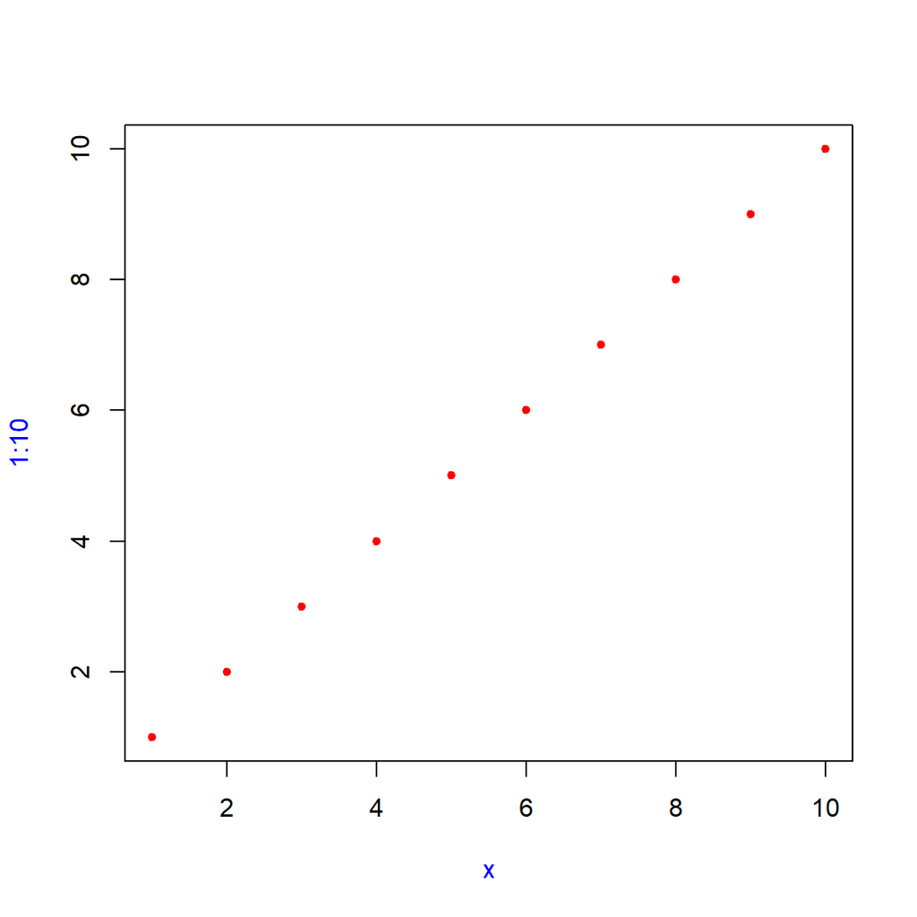

```r
plot(1:10, col = "red", pch = 20, xlab = "x", col.lab = "blue")
```

## 6.7 退出一个函数

### 6.7.1 隐式返回值和显示返回值

```r
j01 <- function(x) {
  if (x < 10) {
    0
  } else {
    10
  }
}
j01(5)
```

```
[1] 0
```

```r
j01(15)
```

```
[1] 10
```

```r
j02 <- function(x) {
  if (x < 10) {
    return(0)
  } else {
    return(10)
  }
}
j02(5)
```

```
[1] 0
```

```r
j02(15)
```

```
[1] 10
```

```r
map(c(1,100),~j02(.x))
```

```
[[1]]
[1] 0

[[2]]
[1] 10
```

### 6.7.2 Invisible values

大多数函数都会明显返回：在交互式上下文中调用该函数会打印结果。

```r
j03 <- function() 1
j03()
```

```
[1] 1
```

但是，可以通过应用invisible()最后一个值来防止自动打印：

```r
j04 <- function() invisible(1)
j04()
```

要验证此值确实存在，可以显式打印或将其包装在括号中：

```r
(j04())
```

```
[1] 1
```

```r
print(j04())
```

```
[1] 1
```

隐式返回的最常见函数是<-：

```r
a <- 2
(a <- 2)
```

```
[1] 2
```

这使得链接分配成为可能：

```r
a <- b <- c <- d <- 2
```

### 6.7.3 错误

如果某个函数无法完成其分配的任务，则应使用抛出错误`stop()`，该错误会立即终止该函数的执行。

```r
j05 <- function() {
  stop("I'm an error")
  return(10)
}
j05()
```

```
Error in j05(): I'm an error
```

错误表明出了点问题，并迫使用户处理问题。某些语言（例如C，Go和Rust）依赖于特殊的返回值来指示问题，但是在R中，您应始终抛出错误。在第8章中，您将学到更多有关错误以及如何处理错误的信息。

### 6.7.4 Exit handlers

有时，某个功能需要对全局状态进行临时更改。但是必须清理这些更改可能会很痛苦（如果发生错误会发生什么？）。为确保撤消这些更改并确保无论函数如何退出都将恢复全局状态，请使用on.exit()设置退出处理程序。以下简单示例显示，无论函数正常退出还是出现错误，退出处理程序都将运行

```r
j06 <- function(x) {
  cat("Hello\n")
  on.exit(cat("Goodbye!\n"), add = TRUE)

  if (x) {
    return(10)
  } else {
    stop("Error")
  }
}

j06(TRUE)
```

```
Hello
Goodbye!
```

```
[1] 10
```

**练习**

## 6.8 函数形式

### 6.8.1 重写为前缀形式

```r
x + y
```

```
numeric(0)
```

```r
`+`(x, y)
```

```
numeric(0)
```

### 6.8.2 前缀形式

- 按位置，例如help(mean)。
- 使用部分匹配，例如help(top = mean)。
- 按名称命名，例如help(topic = mean)。

```r
k01 <- function(abcdef, bcde1, bcde2) {
  list(a = abcdef, b1 = bcde1, b2 = bcde2)
}
str(k01(1, 2, 3))
```

```
List of 3
 $ a : num 1
 $ b1: num 2
 $ b2: num 3
```

```r
str(k01(2, 3, abcdef = 1))
```

```
List of 3
 $ a : num 1
 $ b1: num 2
 $ b2: num 3
```

通常，仅对第一个或第二个参数使用位置匹配。它们将是最常用的，大多数读者将知道它们是什么。避免对不太常用的参数使用位置匹配，并且永远不要使用部分匹配。不幸的是，您不能禁用部分匹配，但是可以通过以下warnPartialMatchArgs选项将其变为警告：

```r
options(warnPartialMatchArgs = TRUE)
x <- k01(a = 1, 2, 3)
```

```
Warning in k01(a = 1, 2, 3): 'a'部分匹配为'abcdef'
```

```r
x
```

```
$a
[1] 1

$b1
[1] 2

$b2
[1] 3
```

### 6.8.3 Infix函数

```r
`%-%` <- function(a, b) paste0("(", a, " %-% ", b, ")")
"a" %-% "b" %-% "c"
```

```
[1] "((a %-% b) %-% c)"
```

### 6.8.4 替代函数

### 6.8.5 特殊形式

**练习**

### 6.8.6 [本章答案](https://advanced-r-solutions.rbind.io/functions.html)

问: 可以（尽管通常没有用）调用匿名函数。以下两种方法中的哪一种是正确的？为什么？

```r
function(x) 3()
```

```
function(x) 3()
```

```
#> function(x) 3()
```

```r
(function(x) 3)()
```

```
[1] 3
```

```
#> [1] 3
```

问：一个好的经验法则是匿名函数应该放在一行上，不需要使用{}。查看您的代码。您在哪里可以使用匿名函数而不是命名函数？您应该在哪里使用命名函数而不是匿名函数？

答：在某些情况下，**使用匿名函数可以使代码简洁明了**。但是，他们错过了一个描述性的名称，并且在重新阅读代码时可能需要一段时间才能弄清楚他们的所作所为（即使您将来阅读也是如此）。因此，给长而复杂的函数起一个描述性的名称是有帮助的。可能值得看看您自己的项目或其他人的代码以反映您的编码风格的这一部分。

问：函数的三个重要组成部分是什么？

这些组件是函数的`body()`，`formals()`和`environment()`。但是，如教科书所述：

> 函数具有三个组成部分的规则是一个例外。诸如的原始函数sum()直接使用.Primitive()而不包含R代码来调用C 代码。因此他们的formals()，body()和environment()都是NULL。

问：打印功能什么时候不显示其创建的环境？

答：原始函数和在全局环境中创建的函数不会打印其环境。

# 7 环境

## 7.1 介绍

环境是为作用域提供支持的数据结构。本章深入研究环境，深入描述其结构，并使用它们来增进您对6.4节中描述的四个范围界定规则的理解。日常使用R并不需要了解环境。但是要理解它们很重要，因为它们支持许多重要的R功能（如词法作用域，名称空间和R6类），并与评估交互以提供强大的工具来进行领域开发特定语言，例如dplyr和ggplot2。

`Rlang`中的 `env` 函数被设计用于管道:所有函数都以环境作为第一个参数，许多函数还返回一个环境。为了使代码尽可能简单，我不会在本章中使用管道，但是您应该考虑使用自己的代码。

## 7.2 环境基础

通常，环境类似于命名列表，但有四个重要例外：

- 每个名称都必须唯一。
- 环境中的名称没有顺序。
- 环境有一个父级。
- 修改后不会复制环境。

```r
library(rlang)
e1 <- env(
  a = FALSE,
  b = "a",
  c = 2.3,
  d = 1:3,
)
e1
```

```
<environment: 0x00000000236d9658>
```

```r
e1$d <- e1

e1
```

```
<environment: 0x00000000236d9658>
```

打印环境仅显示其内存地址，这并不是非常有用：

```r
e1 %>% env_print()
```

```
<environment: 00000000236D9658>
parent: <environment: global>
bindings:
 * a: <lgl>
 * b: <chr>
 * c: <dbl>
 * d: <env>
```

```r
e1 %>% env_parent()
```

```
<environment: R_GlobalEnv>
```

```r
e1 %>% env_names()
```

```
[1] "a" "b" "c" "d"
```

要比较环境，您需要使用`identical()`而不是`==`。这是因为==是向量化运算符，而环境不是向量。

```r
global_env() %>% identical(current_env())
```

```
[1] FALSE
```

```r
identical(global_env(), current_env())
```

```
[1] TRUE
```

每个环境都有一个**父环境**，另一个环境。父级是用来实现词法作用域的：如果在环境中找不到名称，则R将在其**父级中查找**（依此类推）。您可以通过向提供一个未命名的参数来设置父环境`env()`。如果不提供，则默认为当前环境。在下面的代码中，**e2a是的父级e2b**。

```r
e2a <- env(d = 4, e = 5)
e2b <- env(e2a, a = 1, b = 2, c = 3)
e2a %>% env_parent()
```

```
<environment: R_GlobalEnv>
```

```r
e2b %>% env_parent()
```

```
<environment: 0x000000001f8d93b0>
```

```r
e2c <- env(empty_env(), d = 4, e = 5)
e2d <- env(e2c, a = 1, b = 2, c = 3)

e2d %>% env_parent()
```

```
<environment: 0x000000002371cda8>
```

```r
e2c
```

```
<environment: 0x000000002371cda8>
```

```r
e2c %>% env_parents()
```

```
[[1]] $ <env: empty>
```

```r
e2c %>% env_parent()
```

```
<environment: R_EmptyEnv>
```

只有一个环境没有父级：**空环境**

每个环境的祖先最终都以**空环境**终止。您可以通过以下方式查看所有祖先`env_parents()`：

```r
e2b %>% env_print()
```

```
<environment: 0000000022D76170>
parent: <environment: 000000001F8D93B0>
bindings:
 * a: <dbl>
 * b: <dbl>
 * c: <dbl>
```

```r
e2b %>% env_parents()
```

```
[[1]]   <env: 000000001F8D93B0>
[[2]] $ <env: global>
```

```r
e2c %>% env_print()
```

```
<environment: 000000002371CDA8>
parent: <environment: empty>
bindings:
 * d: <dbl>
 * e: <dbl>
```

```r
e2c %>% env_parents()
```

```
[[1]] $ <env: empty>
```

```r
e2d %>% env_print()
```

```
<environment: 0000000020944F00>
parent: <environment: 000000002371CDA8>
bindings:
 * a: <dbl>
 * b: <dbl>
 * c: <dbl>
```

```r
e2d %>% env_parents()
```

```
[[1]]   <env: 000000002371CDA8>
[[2]] $ <env: empty>
```

默认情况下，`env_parents()`到达全局环境时停止。这很有用，因为全局环境的祖先包括每个附加的程序包，您可以查看它们是否覆盖了以下默认行为。

```r
e2b %>% env_print()
```

```
<environment: 0000000022D76170>
parent: <environment: 000000001F8D93B0>
bindings:
 * a: <dbl>
 * b: <dbl>
 * c: <dbl>
```

```r
e2b %>% env_names()
```

```
[1] "a" "b" "c"
```

```r
e2b %>% env_parents()
```

```
[[1]]   <env: 000000001F8D93B0>
[[2]] $ <env: global>
```

```r
env_parents(e2b,last = empty_env())
```

```
 [[1]]   <env: 000000001F8D93B0>
 [[2]] $ <env: global>
 [[3]] $ <env: package:rlang>
 [[4]] $ <env: package:lubridate>
 [[5]] $ <env: package:vtable>
 [[6]] $ <env: package:kableExtra>
 [[7]] $ <env: package:explore>
 [[8]] $ <env: package:DataExplorer>
 [[9]] $ <env: package:skimr>
[[10]] $ <env: package:DT>
[[11]] $ <env: package:forcats>
[[12]] $ <env: package:stringr>
[[13]] $ <env: package:dplyr>
[[14]] $ <env: package:purrr>
[[15]] $ <env: package:readr>
[[16]] $ <env: package:tidyr>
[[17]] $ <env: package:tibble>
[[18]] $ <env: package:tidyverse>
[[19]] $ <env: package:pacman>
[[20]] $ <env: package:rmdformats>
... and 13 more environments
```

常规赋值<-总是在当前环境中创建一个变量。超级赋值<<-永远不会在当前环境中创建变量，而是修改在父环境中找到的现有变量。

```r
x <- 0
f <- function() {
  x <<- 1
}
f()
x
```

```
[1] 1
```

如果<<-找不到现有变量，它将在全局环境中创建一个。这通常是不希望的，因为全局变量在函数之间引入了非显而易见的依赖关系。

您可以使用`$`和`[[`以与列表相同的方式获取和设置环境的元素：

```r
e3 <- env(x = 1, y = 2)
e3$x
```

```
[1] 1
```

```r
e3$y
```

```
[1] 2
```

```r
e3$z <- 3
e3 %>% env_print()
```

```
<environment: 00000000188EB938>
parent: <environment: global>
bindings:
 * x: <dbl>
 * y: <dbl>
 * z: <dbl>
```

```r
e3[["z"]]
```

```
[1] 3
```

还有两种将绑定添加到环境的方法：

```r
env_poke(e3,"a",100)
e3$a
```

```
[1] 100
```

```r
env_bind(e3,a = 10,b = 20)
e3
```

```
<environment: 0x00000000188eb938>
```

```r
e3 %>% env_print()
```

```
<environment: 00000000188EB938>
parent: <environment: global>
bindings:
 * x: <dbl>
 * y: <dbl>
 * z: <dbl>
 * a: <dbl>
 * b: <dbl>
```

您可以使用函数`env_has()`确定环境是否与某个元素绑定：

```r
env_has(e3,"a")
```

```
   a
TRUE
```

与列表不同，将元素设置为`NULL`不会将其删除，因为有时您想要一个引用的名称`NULL`。而是使用`env_unbind()`：

```r
e3$a <- NULL
e3 %>% env_print()
```

```
<environment: 00000000188EB938>
parent: <environment: global>
bindings:
 * x: <dbl>
 * y: <dbl>
 * z: <dbl>
 * a: <NULL>
 * b: <dbl>
```

```r
env_unbind(e3,"a")
e3 %>% env_print()
```

```
<environment: 00000000188EB938>
parent: <environment: global>
bindings:
 * x: <dbl>
 * y: <dbl>
 * z: <dbl>
 * b: <dbl>
```

**取消绑定名称**不会删除该对象。这就是垃圾收集器的工作，垃圾收集器自动删除没有名称绑定到对象的对象。

- `env_bind_lazy()`创建延迟绑定，该绑定在首次访问时进行评估。在后台，延迟绑定会创建Promise，因此其行为与函数参数相同。

```r
env_bind_lazy(current_env(), b = {Sys.sleep(1); 1})

system.time(print(b))
```

```
[1] 1
```

```
   user  system elapsed
      0       0       1
```

```
#> [1] 1
#>    user  system elapsed
#>       0       0       1
```

```r
system.time(print(b))
```

```
[1] 1
```

```
   user  system elapsed
      0       0       0
```

```
#> [1] 1
#>    user  system elapsed
#>       0       0       0
```

- `env_bind_active()`创建活动绑定，每次访问它们都会重新计算：

```r
env_bind_active(current_env(), z1 = function(val) runif(1))
z1
```

```
[1] 0.3521718
```

**练习**

```r
e1 <- env(a = "loop")
e1 %>% env_print()
```

```
<environment: 000000002195F7C0>
parent: <environment: global>
bindings:
 * a: <chr>
```

```r
e1$a <- e1
e1 %>% env_print()
```

```
<environment: 000000002195F7C0>
parent: <environment: global>
bindings:
 * a: <env>
```

```r
e1$a
```

```
<environment: 0x000000002195f7c0>
```

```r
e1 <- env()
e1$a <- e1
e1 %>% env_print()
```

```
<environment: 0000000020DC82D0>
parent: <environment: global>
bindings:
 * a: <env>
```

```r
e1 <- env(a = "loop")
e2 <- env(a = "dedoop")
e1$b <- e2
e2$b <- e1
env_print(e1)
```

```
<environment: 000000001FA43CA8>
parent: <environment: global>
bindings:
 * a: <chr>
 * b: <env>
```

```r
e1$a
```

```
[1] "loop"
```

```r
e1 %>% env_parents()
```

```
[[1]] $ <env: global>
```

```r
e1$a
```

```
[1] "loop"
```

```r
e1$b
```

```
<environment: 0x000000001f8ae6f0>
```

```r
env(e1,a = 1) %>% env_parents()
```

```
[[1]]   <env: 000000001FA43CA8>
[[2]] $ <env: global>
```

```r
env(b = e1,a = 1) %>% env_parents()
```

```
[[1]] $ <env: global>
```

## 7.3 在环境中递归

如果希望对环境的每个祖先进行操作，编写递归函数通常很方便。本节将向您展示如何应用您对环境的新知识编写一个给定名称的函数，并使用 r 的常规作用域规则查找定义该名称的环境。

`Where()`的定义很简单。它有两个参数:要查找的名称(作为字符串)和开始搜索的环境。(我们将在7.5节中了解caller_env()为什么是一个很好的缺省值。)

```r
where <- function(name, env = caller_env()) {
  if (identical(env, empty_env())) {
    # Base case
    stop("Can't find ", name, call. = FALSE)
  } else if (env_has(env, name)) {
    # Success case
    env
  } else {
    # Recursive case
    where(name, env_parent(env))
  }
}
where("yyy")
```

```
Error: Can't find yyy
```

```r
x <- 5
where("x")
```

```
<environment: R_GlobalEnv>
```

```r
where("mean")
```

```
<environment: base>
```

```r
e4a <- env(empty_env(),a = 1,b = 2)
e4a %>%
  env_print()
```

```
<environment: 0000000018417CC0>
parent: <environment: empty>
bindings:
 * a: <dbl>
 * b: <dbl>
```

```r
e4b <- env(e4a,x = 10,a = 11)
e4b %>% env_print()
```

```
<environment: 000000001401FF48>
parent: <environment: 0000000018417CC0>
bindings:
 * x: <dbl>
 * a: <dbl>
```

```r
e4b %>% env_parents()
```

```
[[1]]   <env: 0000000018417CC0>
[[2]] $ <env: empty>
```

## 7.4 特殊环境

大多数环境不是由您创建的(例如使用env())，而是由r创建的。在本节中，您将了解最重要的环境，从包环境开始。然后您将了解在创建函数时绑定到该函数的函数环境，以及(通常)在每次调用该函数时创建临时执行环境。最后，您将看到包和函数环境如何交互以支持名称空间，这确保包始终以相同的方式运行，而不管用户加载了哪些其他包。

如果你追踪所有的父母回来，你会看到每个包裹被附上的顺序。这被称为搜索路径，因为这些环境中的所有对象都可以从顶级交互式工作区中找到。您可以使用`base::search()`查看这些环境的名称，或者使用`rlang::search_envs()`查看这些环境本身:

```r
search()
```

```
 [1] ".GlobalEnv"           "package:rlang"        "package:lubridate"
 [4] "package:vtable"       "package:kableExtra"   "package:explore"
 [7] "package:DataExplorer" "package:skimr"        "package:DT"
[10] "package:forcats"      "package:stringr"      "package:dplyr"
[13] "package:purrr"        "package:readr"        "package:tidyr"
[16] "package:tibble"       "package:tidyverse"    "package:pacman"
[19] "package:rmdformats"   "package:lobstr"       "package:knitr"
[22] "package:stats"        "package:graphics"     "package:utils"
[25] "package:datasets"     "package:ggplot2"      "package:grDevices"
[28] "package:extrafont"    "package:methods"      "Autoloads"
[31] "package:base"
```

```r
search_envs()
```

```
 [[1]] $ <env: global>
 [[2]] $ <env: package:rlang>
 [[3]] $ <env: package:lubridate>
 [[4]] $ <env: package:vtable>
 [[5]] $ <env: package:kableExtra>
 [[6]] $ <env: package:explore>
 [[7]] $ <env: package:DataExplorer>
 [[8]] $ <env: package:skimr>
 [[9]] $ <env: package:DT>
[[10]] $ <env: package:forcats>
[[11]] $ <env: package:stringr>
[[12]] $ <env: package:dplyr>
[[13]] $ <env: package:purrr>
[[14]] $ <env: package:readr>
[[15]] $ <env: package:tidyr>
[[16]] $ <env: package:tibble>
[[17]] $ <env: package:tidyverse>
[[18]] $ <env: package:pacman>
[[19]] $ <env: package:rmdformats>
[[20]] $ <env: package:lobstr>
... and 11 more environments
```

您可以使用`fn_env()`获得函数环境：

```r
y <- 1
f <- function(x) x + y
f(1)
```

```
[1] 2
```

```r
body(f)
```

```
x + y
```

```r
formals(f)
```

```r
environment(f)
```

```
<environment: R_GlobalEnv>
```

```r
fn_env(f)
```

```
<environment: R_GlobalEnv>
```

```r
sd
```

```
function (x, na.rm = FALSE)
sqrt(var(if (is.vector(x) || is.factor(x)) x else as.double(x),
    na.rm = na.rm))
<bytecode: 0x00000000234299b0>
<environment: namespace:stats>
```

```r
env_has(current_env(),"a")
```

```
   a
TRUE
```

```r
g <- function(x) {
  if (!env_has(current_env(), "a")) {
    message("Defining a")
    a <- 1
  } else {
    a <- a + 1
  }
  a
}
g()
```

```
Defining a
```

```
[1] 1
```

## 7.5 调用栈

## 7.6 作为数据结构

- 有四种方法：**环境中的每个对象都必须有一个名称**；**顺序无关紧要**；**环境有父级**；**环境具有参考语义**。
- 全局环境的父级是您加载的最后一个软件包。没有父级的唯一环境是**空环境**。
- 函数的封闭环境是创建函数的环境。它确定函数在哪里寻找变量。
- 使用`caller_env()`或`parent.frame()`。
- `<-`总是在当前环境中创建绑定；`<<-`重新绑定当前环境的父级中的现有名称。

## 7.7 [本章答案](https://advanced-r-solutions.rbind.io/environments.html)

Q: List three ways in which an environment differs from a list.

A: The most important differences between environments and lists are:

- environments have reference semantics (i.e. they don’t copy-on-modify).
- environments have parents
- the contents of an environment are not ordered
- the contents of an environment must have unique names

```r
e1 <- env()
e1 %>% env_print()
```

```
<environment: 00000000217F99F0>
parent: <environment: global>
```

```r
e1 %>% env_parent()
```

```
<environment: R_GlobalEnv>
```

```r
e1$loop <- e1
e1 %>% env_print()
```

```
<environment: 00000000217F99F0>
parent: <environment: global>
bindings:
 * loop: <env>
```

```r
e1 <- env()
e2 <- env()

e1$loop   <- e2
e2$dedoop <- e1
e1 %>% env_print()
```

```
<environment: 0000000021BC0800>
parent: <environment: global>
bindings:
 * loop: <env>
```

```r
e2 %>% env_parents()
```

```
[[1]] $ <env: global>
```

```r
e2 %>% env_print()
```

```
<environment: 00000000249703D0>
parent: <environment: global>
bindings:
 * dedoop: <env>
```

# 8 条件

## 8.1 介绍

**条件系统**提供了成对的工具集，这些工具使函数的创建者可以指示正在发生异常情况，并且该函数的用户可以对其进行处理。 函数作者使用`stop（）`（对于错误），`warning（）`（对于警告）和`message（）`（对于消息）之类的函数来表示条件，然后函数用户可以使用`tryCatch（）`和`withCallingHandlers（）`之类的函数来处理它们。了解条件系统很重要，因为您经常需要同时**扮演两个角色**：从您创建的函数中发出条件信号，并处理由调用函数发出的信号。

R提供了一个基于`Common Lisp`的思想的非常强大的条件系统。与R的面向对象编程方法一样，它与当前流行的编程语言也有很大不同，因此很容易造成误解，而且关于如何有效地使用它的文字也很少。从历史上看，这意味着很少有人（包括我本人）充分利用它的功能。本章的目的是纠正这种情况。在这里，您将了解**R条件系统**的重要构想，并学习**一系列实用工具**，以使您的代码更强大。

```r
library(rlang)
```

## 8.2 Signalling conditions

您可以用代码表示三种情况：错误，警告和消息。

- **错误**是最严重的；它们表明函数无法继续执行并且必须停止执行。
- **警告**介于错误和消息之间，通常表示出现了问题，但该功能至少能够部分恢复。
- **信息**最温和； 它们是通知用户已代表他们执行了某些操作的方式。

最后的条件只能以交互方式生成：中断，表明用户已通过按`Escape`，`Ctrl + Break`或`Ctrl + C`（取决于平台）来中断执行。

根据R界面，条件通常以醒目的字体显示为粗体或红色。您可以将它们区分开来，因为错误总是以“错误”开头，警告总是以“警告”或“警告消息”开头，而没有任何消息。

```r
stop("This is what a error looks like")
```

```
Error in eval(expr, envir, enclos): This is what a error looks like
```

```r
warning("This is what a warning looks like")
```

```
Warning: This is what a warning looks like
```

```r
message("This is what a message looks like")
```

```
This is what a message looks like
```

```r
f <- function() g()
g <- function() h()
h <- function() stop("This is a error")
f()
```

```
Error in h(): This is a error
```

相当于`stop（）`的rlang，`rlang::abort（）`会自动执行此操作。在本章中，我们将使用`abort（）`，但直到其接近本章末尾，我们才能使用其最引人注目的功能，即向条件对象添加其他元数据的功能。

```r
h <- function() abort("This is a error")
f()
```

```
Error: This is a error
```

```r
f1 <- function(x,y){
  x + y
}
map2(1:3,1:3,f1)
```

```
[[1]]
[1] 2

[[2]]
[1] 4

[[3]]
[1] 6
```

```r
f1 <- function(x,y,z){
  x + y + z
}
pmap(list(x = 1:3,y = 1:3,z = 1:3),f1)
```

```
[[1]]
[1] 3

[[2]]
[1] 6

[[3]]
[1] 9
```

```r
fw <- function(){
  cat("1\n")
  warning("W1")
  cat("2\n")
  warning("W2")
  cat("3\n")
  warning("W3")
}

fw()
```

```
1
```

```
2
```

```
Warning in fw(): W2
```

```
3
```

```
Warning in fw(): W3
```

警告在消息（“您应该知道这一点”）和错误（“您必须解决此问题！”）之间占据颇具挑战性的位置，很难就何时使用它们给出准确的建议。通常，请保持克制，因为如果有很多其他输出，警告很容易丢失，并且您不希望函数从明显无效的输入中恢复太容易。我认为，基数R倾向于过度使用警告，而基数R中的许多警告会更好地作为错误。 例如，我认为这些警告作为错误更有用：

```r
formals(2)
```

```
Warning in formals(fun): argument is not a function
```

```r
file.remove("this is a filename")
```

```
[1] FALSE
```

```r
stats::lag(1:3,k = 1.5)
```

```
[1] 1 2 3
attr(,"tsp")
[1] -1  1  1
```

```r
fm <- function() {
  cat("1\n")
  message("M1")
  cat("2\n")
  message("M2")
  cat("3\n")
  message("M3")
}

fm()
```

```
1
```

```
M1
```

```
2
```

```
M2
```

```
3
```

```
M3
```

使用消息的好地方是：

- 当**默认参数**需要一定数量的计算时，您想告诉用户使用了什么值。例如，如果您没有提供`binwidth`，ggplot2会报告使用的**bin数量**。
- 在主要因副作用而调用的函数中，否则将保持沉默。例如，在将文件写入磁盘，调用Web API或写入数据库时 ，定期提供状态消息来告诉用户正在发生的事情非常有用。
- 当您要开始长时间运行且没有中间输出的过程时。进度条（例如进度条）比较好，但是一条消息是开始的好地方。
- 编写软件包时，有时您希望在加载软件包时显示一条消息（例如，在.onAttach（）中）； 在这里，您必须使用`packageStartupMessage（）`。

比较`message（）`和密切相关的`cat（）`很重要。就用法和结果而言，它们看起来非常相似:

```r
cat("Hi!\n")
```

```
Hi!
```

```r
message("Hi!\n")
```

```
Hi!
```

但是，`cat（）`和`message（）`的用途不同。当函数的主要作用是打印到控制台时，请使用`cat（）`，例如`print（）`或`str（）`方法。当该函数的主要目的是其他目的时，请使用`message（）`作为打印到控制台的辅助渠道。换句话说，`cat（）`用于用户要求打印某些内容，而`message（）`用于开发人员选择打印某些内容。

**练习**

围绕file.remove（）编写一个包装，如果要删除的文件不存在，则会引发错误。

```r
file.remove("this")
```

```
[1] FALSE
```

```r
file_exists <- function(x){
  if(file.exists(x)){
    file.remove(x)
  } else {
   stop("This file does not exist!")
  }
}

file_exists("result")
```

```
Error in file_exists("result"): This file does not exist!
```

## 8.3 Ignoring conditions

处理R中条件的最简单方法是简单地忽略它们：

- Ignore errors with `try()`.
- Ignore warnings with `suppressWarnings()`.
- Ignore messages with `suppressMessages()`.

`try（）`允许即使在发生错误后也可以继续执行。通常，如果您运行的函数会引发错误，则该函数会立即终止并且不会返回任何值：

```r
f1 <- function(x){
  log(x)
  10
}
f1(1)
```

```
[1] 10
```

```r
f1("x")
```

```
Error in log(x): 数学函数中用了非数值参数
```

但是，如果将创建错误的语句包装在`try（）`中，则会显示错误消息，但执行将继续：

```r
f1 <- function(x){
  try(log(x))
  10
}

f1(10)
```

```
[1] 10
```

```r
f1("10")
```

```
Error in log(x) : 数学函数中用了非数值参数
```

```
[1] 10
```

`suppressWarnings ()`和`suppressMessages()`取消所有警告和消息。与错误不同，消息和警告不会终止执行，因此在单个块中可能会有多个警告和警告信号。

```r
suppressWarnings({
  warning("Uhoh!")
  warning("Another warning")
  1
})
```

```
[1] 1
```

```r
suppressMessages({
  message("Hello there")
  2
})
```

```
[1] 2
```

```r
suppressWarnings({
  message("You can still see me!")
  3
})
```

```
You can still see me!
```

```
[1] 3
```

## 8.4 Handling conditions

```r
tryCatch(
  error = function(cnd) {
    # code to run when error is thrown
  },
  code_to_run_while_handlers_are_active
)

withCallingHandlers(
  warning = function(cnd) {
    # code to run when warning is signalled
  },
  message = function(cnd) {
    # code to run when message is signalled
  },
  code_to_run_while_handlers_are_active
)
```

```r
cnd <- catch_cnd(stop("An error"))
str(cnd)
```

```
List of 2
 $ message: chr "An error"
 $ call   : language force(expr)
 - attr(*, "class")= chr [1:3] "simpleError" "error" "condition"
```

## 8.5 Custom conditions

## 8.6 应用

## 8.7 [本章答案](https://advanced-r-solutions.rbind.io/conditions.html)

Q: Write a wrapper around `file.remove()` that throws an error if the file to be deleted does not exist.

```r
file_remove_strict <- function(path){
  if(!file.exists(path)){
    stop("Can not delete"," `",path,"` ","because it does not exist.",call. = FALSE)
  } else {
    file.remove(path)
  }
}
file_remove_strict("iris")
```

```
Error: Can not delete `iris` because it does not exist.
```

```r
saveRDS(iris,here::here("code/iris.rds"))
file_remove_strict(here::here("code/iris.rds"))
```

```
[1] TRUE
```

Q: What does the `appendLF` argument to `message()` do? How is it related to `cat()`?

```r
multiline_msg <- function(appendLF){
  message("first",appendLF = appendLF)
  cat("second")
  cat("third")
}
multiline_msg(appendLF = TRUE)
```

```
first
```

```
secondthird
```

```r
multiline_msg(appendLF = FALSE)
```

```
first
```

```
secondthird
```

问：与`stop（）`生成的条件相比，`abort（）`生成的条件包含哪些额外信息？ 即这两个对象有什么区别？ 阅读有关`？abort`的帮助以了解更多信息。

```r
str(catch_cnd(stop("An error")))
```

```
List of 2
 $ message: chr "An error"
 $ call   : language force(expr)
 - attr(*, "class")= chr [1:3] "simpleError" "error" "condition"
```

```r
str(catch_cnd(abort("An error")))
```

[output not shown]